# Predicción de Supervivencia en Pacientes con Cáncer: Análisis Exploratorio, Preprocesamiento de Datos, creación de modelos de machine learning, optimización y comparación

# ÍNDICE

1. Introducción
2. Metodología
   1. Selección del Dataset
   2. Exploración de Datos
   3. Identificación de Datos Faltantes
   4. Imputación de valores faltantes
   5. Preparación de los datos
   6. Dataset final
3. Diseño y comparativa de redes neuronales
   1. Consideraciones iniciales de estructura de los modelos
   2. Creación de los primeros modelos
   3. Modelos sin división de subredes específicas por tipo de cáncer
   4. Comparativa con autoencoders y SVM para valorar las métricas obtenidas
4. Optimización del mejor modelo
   1. Optimización con Optuna
   2. Random search
   3. Grid Search

## 1. INTRODUCCIÓN

El objetivo principal de este estudio es preparar el dataset para desarrollar un modelo óptimo de clasificación de supervivencia en cáncer. Se analizarán valores faltantes, variables específicas por tipo de cáncer y estrategias de normalización antes de la fase de modelado.

## 2. METODOLOGÍA

### 2.1. Selección del Dataset

```python
# Abrimos el dataset
import pandas as pd

# Especifica la ruta al archivo
#file_path = "C:/Users/Juan/Documents/Master UOC/TFM/msk_chord_2024_clinical_data.tsv"
file_url = "https://raw.githubusercontent.com/JuanGonzalezBallester/TFM/main/msk_chord_2024_clinical_data.tsv"
# Lee el archivo TSV
try:
    data = pd.read_csv(file_url, sep='\t')
    # Muestra las primeras filas del dataset
    print("Dataset cargado exitosamente:")
    print(data.head())
except FileNotFoundError:
    print("Archivo no encontrado. Por favor, verifica la ruta del archivo.")
except Exception as e:
    print(f"Ocurrió un error al cargar el archivo: {e}")
```

```
Dataset cargado exitosamente:
         Study ID Patient ID          Sample ID  \
0  msk_chord_2024  P-0000012  P-0000012-T02-IM3
1  msk_chord_2024  P-0000012  P-0000012-T03-IM3
2  msk_chord_2024  P-0000015  P-0000015-T01-IM3
3  msk_chord_2024  P-0000036  P-0000036-T01-IM3
4  msk_chord_2024  P-0000041  P-0000041-T01-IM3

  Tumor Site: Adrenal Glands (NLP) Tumor Site: Bone (NLP)  \
0                               No                     No
1                               No                     No
2                               No                    Yes
3                               No                    Yes
4                               No                    Yes

```

[output cut: 43 more lines]

### 2.2. Exploración de Datos

- Número total de filas en el dataset: 25,040
- Número total de pacientes: 24,950
- Número total de columnas: 53

Las primeras filas muestran una amplia variedad de información clínica, incluyendo:

- Diagnóstico de cáncer
- Detalles de mutaciones genómicas
- Historial de tratamiento
- Etapas de enfermedad
- Estado de supervivencia

```
Número total de filas: 25040
**Valores Únicos por Atributo:**
- Study ID (Tipo de dato: object):
  - Valores únicos: ['msk_chord_2024']
  - Cantidad de valores únicos: 1

- Patient ID (Tipo de dato: object):
  - Valores únicos: ['P-0000012' 'P-0000015' 'P-0000036' 'P-0000041' 'P-0000057']...
  - Cantidad de valores únicos: 24950

- Sample ID (Tipo de dato: object):
  - Valores únicos: ['P-0000012-T02-IM3' 'P-0000012-T03-IM3' 'P-0000015-T01-IM3'
 'P-0000036-T01-IM3' 'P-0000041-T01-IM3']...
  - Cantidad de valores únicos: 25040

- Tumor Site: Adrenal Glands (NLP) (Tipo de dato: object):
  - Valores únicos: ['No' 'Yes' 'Unknown']
  - Cantidad de valores únicos: 3

- Tumor Site: Bone (NLP) (Tipo de dato: object):
  - Valores únicos: ['No' 'Yes' 'Unknown']
  - Cantidad de valores únicos: 3

- Cancer Type (Tipo de dato: object):
  - Valores únicos: ['Breast Cancer' 'Non-Small Cell Lung Cancer' 'Colorectal Cancer'
 'Prostate Cancer' 'Pancreatic Cancer']
  - Cantidad de valores únicos: 5

- Cancer Type Detailed (Tipo de dato: object):
  - Valores únicos: ['Breast Invasive Ductal Carcinoma' 'Lung Adenocarcinoma'
 'Breast Mixed Ductal and Lobular Carcinoma' 'Colon Adenocarcinoma'
 'Breast Invasive Lobular Carcinoma']...
  - Cantidad de valores únicos: 63

- Clinical Group (Tipo de dato: object):
  - Valores únicos: [nan '3B' '1' '4' '2A']...
  - Cantidad de valores únicos: 23

- Clinical Summary (Tipo de dato: object):
  - Valores únicos: [nan 'Distant' 'Localized' 'Regional,Lymph Nodes Only'
```

[output cut: 227 more lines]

```
Tumor Site: Pleura (NLP)                      0
Primary Tumor Site                            0
Prior Treatment to MSK (NLP)                  0
Race                                          0
Tumor Site: Reproductive Organs (NLP)         0
Sample Class                                  0
Number of Samples Per Patient                 0
Sample coverage                               0
Sample Type                                   0
Smoking History (NLP)                         0
Somatic Status                                0
Stage (Highest Recorded)                      0
TMB (nonsynonymous)                           0
Tumor Purity                                586
dtype: int64
```

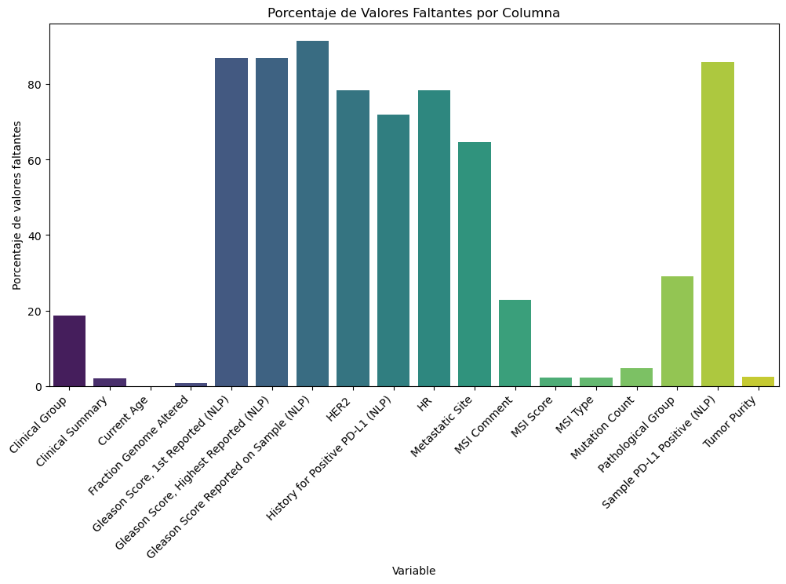

```
**Estadísticas Descriptivas (para columnas numéricas):**
        Current Age  Fraction Genome Altered  \
count  25037.000000             24870.000000
mean      65.476655                 0.180309
std       12.683747                 0.185514
min       10.000000                 0.000000
25%       57.000000                 0.021100
50%       67.000000                 0.125800
75%       75.000000                 0.283900
max       89.000000                 1.000000

       Gleason Score, 1st Reported (NLP)  \
count                        3272.000000
mean                            7.845355
std                             1.022186
min                             6.000000
25%                             7.000000
50%                             8.000000
75%                             9.000000
max                            10.000000

       Gleason Score, Highest Reported (NLP)  \
count                            3272.000000
mean                                7.981663
std                                 0.976473
min                                 6.000000
25%                                 7.000000
50%                                 8.000000
75%                                 9.000000
max                                10.000000

       Gleason Score Reported on Sample (NLP)     MSI Score  Mutation Count  \
count                             2110.000000  24487.000000    23862.000000
mean                                 8.012322      1.438650        8.725756
std                                  0.942561      5.004455       19.416691
min                                  6.000000     -1.000000        1.000000
25%                                  7.000000      0.020000        3.000000
50%                                  8.000000      0.230000        5.000000
75%                                  9.000000      0.900000        8.000000
max                                 10.000000     53.530000      696.000000
```

[output cut: 15 more lines]

```
min                         1.000000        23.000000             0.000000
25%                         1.000000       470.000000             2.461042
50%                         1.000000       598.000000             4.101736
75%                         1.000000       737.000000             6.917585
max                         2.000000      2610.000000           570.961677

       Tumor Purity
count  24454.000000
mean      36.414452
std       19.201781
min        0.000000
25%       20.000000
50%       30.000000
75%       50.000000
max       95.000000
```

```python
import matplotlib.pyplot as plt
import seaborn as sns

# Número total de filas en el dataset
num_rows = data.shape[0]
print(f"Número total de filas: {num_rows}")

# Por atributo: valores únicos y su cantidad
print("**Valores Únicos por Atributo:**")
for column in data.columns:
    unique_values = data[column].unique()
    #print(f"- {column}:")
    print(f"- {column} (Tipo de dato: {data[column].dtype}):")
    print(f"  - Valores únicos: {unique_values[:5]}{'...' if len(unique_values) > 5 else ''}")
    print(f"  - Cantidad de valores únicos: {len(unique_values)}\n")

# Resumen de valores faltantes
print("\n**Valores Faltantes (por columna):**")
print(data.isnull().sum())

# Porcentaje valores faltantes
missing_values = data.isnull().sum()
missing_percentage = (missing_values / len(data)) * 100

# Filtrar columnas con valores faltantes
missing_percentage = missing_percentage[missing_percentage > 0]

# Crear un DataFrame para evitar problemas con Seaborn
missing_df = missing_percentage.reset_index()
missing_df.columns = ["Variable", "Porcentaje"]

# Crear el gráfico corregido
plt.figure(figsize=(12, 6))
sns.barplot(data=missing_df, x="Variable", y="Porcentaje", hue="Variable", palette="viridis", legend=False)
plt.xticks(rotation=45, ha="right")
plt.ylabel("Porcentaje de valores faltantes")
plt.title("Porcentaje de Valores Faltantes por Columna")
plt.show()

# Contar el total de valores NaN en el dataset
#total_nan = data.isnull().sum().sum()
#print(f"\n**Total de valores faltantes en el dataset:** {total_nan}")

# Estadísticas descriptivas del dataset
print("\n**Estadísticas Descriptivas (para columnas numéricas):**")
print(data.describe())
```

### 2.3. Identificación de Datos Faltantes

Se observa una gran cantidad de valores de tipo objeto. Para generar el modelo, los normalizaremos y prepararemos para generar el modelo. También, es importante definir cual es el atributo a predecir (la supervivencia) que en este caso es *Overall Survival Status*. Es importante analizar los casos de cáncer por separado, ya que analizando los valores faltantes, observamos:

Estas pruebas de medida de Gleason sólo aplican al cáncer de próstata.

- Gleason Score, 1st Reported (NLP) 21768
- Gleason Score, Highest Reported (NLP) 21768
- Gleason Score Reported on Sample (NLP) 22930

Estas pruebas, son específicas de cáncer de mama:

- HER2 19648
- HR 19648

Estas pruebas, son específicas de cáncer de pulmón:

- History for Positive PD-L1 (NLP) 17989
- Sample PD-L1 Positive (NLP) 21514

Hay una serie de atributos, que se eliminan por no aportar información al modelo, como los datos individuales de ID del paciente, etc.

- Study ID
- Patient ID
- Sample ID
- Clinical Group 4664
- Clinical Summary 488

Hay situaciones en las que todos los tipos de cáncer, pueden no presentan estas características, por lo que debemos imputar los datos faltantes correctamente:

- Metastatic Site 16206
- MSI Comment 5697
- MSI Score 553
- MSI Type 554
- Mutation Count 1178

El valor categórico con mayor número de valores diferentes es:

- Metastatic Site (Tipo de dato: object):
  - Cantidad de valores únicos: 190

Hay filas con valores faltantes que se deciden eliminar pues es una variables bastante importante, y solo son 3:

- Current Age 3

```python
# Eliminar columnas específicas del dataset
columns_to_drop = ['Study ID', 'Patient ID', 'Sample ID', 'Clinical Group', 'Clinical Summary']

# Crear un nuevo dataset sin esas columnas
data = data.drop(columns=columns_to_drop)

# Eliminar current age vacío
data = data[data['Current Age'].notna()]
```

Para una mejor visualización de los datos, se incluyen herramientas de visualizacion

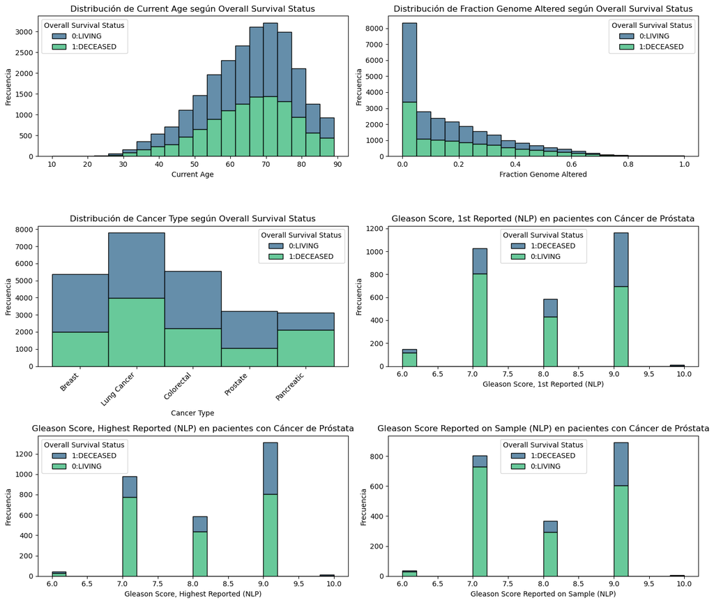

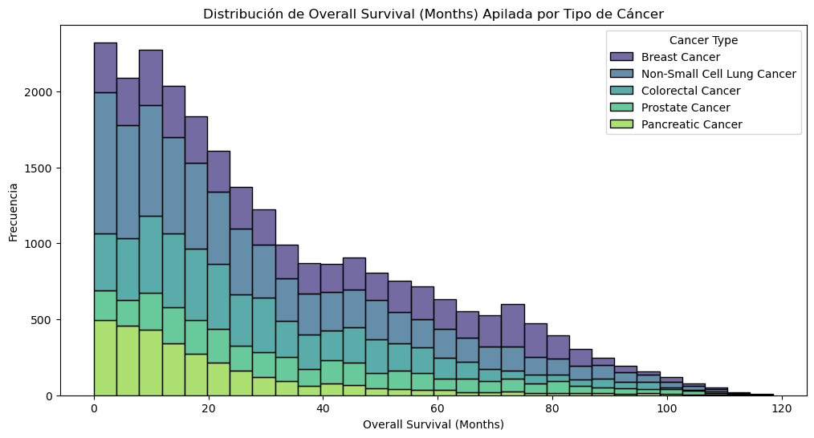

```python
# Visualización de las distribuciones de datos más relevantes
# Definir los nombres personalizados para la gráfica
cancer_type_labels = {
    "Breast Cancer": "Breast",
    "Non-Small Cell Lung Cancer": "Lung Cancer",
    "Colorectal Cancer": "Colorectal",
    "Prostate Cancer": "Prostate",
    "Pancreatic Cancer": "Pancreatic"
}

# Definir las columnas para los gráficos generales
attributes = ["Current Age", "Fraction Genome Altered", "Cancer Type"]

# Filtrar datos de cáncer de próstata para las columnas de Gleason Score
prostate_cancer_data = data[data["Cancer Type"] == "Prostate Cancer"]
gleason_attributes = ["Gleason Score, 1st Reported (NLP)",
                      "Gleason Score, Highest Reported (NLP)",
                      "Gleason Score Reported on Sample (NLP)"]

# Configurar el tamaño de la figura
fig, axes = plt.subplots(nrows=3, ncols=2, figsize=(14, 12))
axes = axes.flatten()

# Generar gráficos de barras apiladas para las variables generales
for i, attr in enumerate(attributes):
    if attr in data.columns:
        ax = sns.histplot(data=data, x=attr, hue="Overall Survival Status", multiple="stack", bins=20, palette="viridis", ax=axes[i])
        axes[i].set_title(f"Distribución de {attr} según Overall Survival Status")
        axes[i].set_xlabel(attr)
        axes[i].set_ylabel("Frecuencia")

        # Modificar los nombres solo en la gráfica
        if attr == "Cancer Type":
            ax.set_xticklabels([cancer_type_labels.get(label, label) for label in data[attr].unique()], rotation=45, ha="right")

# Generar gráficos de barras apiladas solo para Gleason Score en pacientes con cáncer de próstata
for i, attr in enumerate(gleason_attributes):
    if attr in prostate_cancer_data.columns:
        sns.histplot(data=prostate_cancer_data, x=attr, hue="Overall Survival Status", multiple="stack", bins=20, palette="viridis", ax=axes[i + len(attributes)])
        axes[i + len(attributes)].set_title(f"{attr} en pacientes con Cáncer de Próstata")
        axes[i + len(attributes)].set_xlabel(attr)
        axes[i + len(attributes)].set_ylabel("Frecuencia")

# Ajustar el diseño
plt.tight_layout()
plt.show()

# Crear el gráfico de barras apiladas para supervivencia de meses en función del tipo de cancer
plt.figure(figsize=(12, 6))

sns.histplot(data=data, x="Overall Survival (Months)", hue="Cancer Type", multiple="stack", bins=30, palette="viridis")

plt.ylabel("Frecuencia")
plt.xlabel("Overall Survival (Months)")
plt.title("Distribución de Overall Survival (Months) Apilada por Tipo de Cáncer")
plt.show()
```

El modelo presenta la siguiente casuística, los atributos mencionados anteriormente son específicos para tipos de cáncer, es decir, hay columnas que solo aplican, por ejemplo, al cáncer de próstata, pero para el resto son valores faltantes. Habría varias posibilidades de enfocar esto:

- Crear un modelo por tipo de cáncer, lo que optimizaría el resultado y el evitar generalizar no disminuiría la precisión del modelo. Pero, necesitaríamos suficientes datos de cada tipo de cáncer para asegurar un correcto entrenamiento.
- Crear un modelo genérico, imputando valores faltantes, generando un único modelo más fácil de utilizar pero creando ruido por la cantidad de datos faltantes.
- Usar un modelo jerárquico con embeddings específicos, utilizando el tipo de cáncer como característica adicional en el modelo, para que sea posible diferenciar los patrones y procesar correctamente lo valores faltantes.

Finalmente, este último será el utilizado. Se codificará el *Cancer type* como índice numérico para que sea compatible con embeddings.

```python
# Separar atributos específicos
breast_cancer_cols = ['HER2', 'HR']
lung_cancer_cols = ['History for Positive PD-L1 (NLP)', 'Sample PD-L1 Positive (NLP)']
prostate_cancer_cols = ['Gleason Score, 1st Reported (NLP)', 'Gleason Score, Highest Reported (NLP)',
                        'Gleason Score Reported on Sample (NLP)']

# Imputar valores faltantes con 0 para atributos específicos
for col in breast_cancer_cols + lung_cancer_cols + prostate_cancer_cols:
    if col in data.columns:
        data[col] = data[col].fillna(0)

# Verificar columnas faltantes restantes
print("Valores faltantes por columna después de imputación:")
print(data.isnull().sum())
```

```
Valores faltantes por columna después de imputación:
Tumor Site: Adrenal Glands (NLP)              0
Tumor Site: Bone (NLP)                        0
Cancer Type                                   0
Cancer Type Detailed                          0
Tumor Site: CNS/Brain (NLP)                   0
Current Age                                   0
Diagnosis Description                         0
Ethnicity                                     0
Fraction Genome Altered                     170
Sex                                           0
Gene Panel                                    0
Gleason Score, 1st Reported (NLP)             0
Gleason Score, Highest Reported (NLP)         0
Gleason Score Reported on Sample (NLP)        0
HER2                                          0
History for Positive PD-L1 (NLP)              0
HR                                            0
ICD-O Histology Description                   0
Tumor Site: Intra Abdominal                   0
Tumor Site: Liver (NLP)                       0
Tumor Site: Lung (NLP)                        0
Tumor Site: Lymph Node (NLP)                  0
Metastatic Site                           16205
MSI Comment                                5696
MSI Score                                   553
MSI Type                                    554
Mutation Count                             1178
Number of Tumor Registry Entries              0
Oncotree Code                                 0
Overall Survival (Months)                     0
Overall Survival Status                       0
Tumor Site: Other (NLP)                       0
Pathological Group                         7272
Sample PD-L1 Positive (NLP)                   0
Tumor Site: Pleura (NLP)                      0
Primary Tumor Site                            0
Prior Treatment to MSK (NLP)                  0
Race                                          0
Tumor Site: Reproductive Organs (NLP)         0
Sample Class                                  0
Number of Samples Per Patient                 0
Sample coverage                               0
Sample Type                                   0
Smoking History (NLP)                         0
Somatic Status                                0
Stage (Highest Recorded)                      0
TMB (nonsynonymous)                           0
Tumor Purity                                586
dtype: int64
```

### 2.4- Imputación de valores faltantes

El resto de atributos, es necesario analizarlos independientemente:

MSI comment: no deja de ser un comentario sobre el estado de los microsatélites, por lo que decide eliminarse.

MSI Score y MSI Type, aportan gran información, y casi hay los mismos valores faltantes en ambos (Ambos son NA en caso de un NA). Por lo que decide aliminarse las filas para no añadir ruido al modelo.

Fraction Genome Altered, también tiene unos pocos valores nulos, se eliminan las filas.

Para mutation count, utilizaremos un método similar, pues oscila en valores de 1. a 696.

```python
# Eliminar las columnas "Metastatic Site", "MSI Comment" y "Sample Class"
data = data.drop(columns=['Metastatic Site', 'MSI Comment', 'Sample Class'])

# Eliminar las filas con valores nulos en las columnas "MSI Score", "MSI Type" y Fraction Genome Altered
data = data.dropna(subset=['MSI Score', 'MSI Type', 'Fraction Genome Altered'])

# Comprobar el resultado
print(f"Columnas restantes: {data.columns}")
print(f"Número de filas restantes después de eliminación: {data.shape[0]}")

# Verificar columnas faltantes restantes
print("Valores faltantes por columna después de imputación:")
print(data.isnull().sum())
```

```
Columnas restantes: Index(['Tumor Site: Adrenal Glands (NLP)', 'Tumor Site: Bone (NLP)',
       'Cancer Type', 'Cancer Type Detailed', 'Tumor Site: CNS/Brain (NLP)',
       'Current Age', 'Diagnosis Description', 'Ethnicity',
       'Fraction Genome Altered', 'Sex', 'Gene Panel',
       'Gleason Score, 1st Reported (NLP)',
       'Gleason Score, Highest Reported (NLP)',
       'Gleason Score Reported on Sample (NLP)', 'HER2',
       'History for Positive PD-L1 (NLP)', 'HR', 'ICD-O Histology Description',
       'Tumor Site: Intra Abdominal', 'Tumor Site: Liver (NLP)',
       'Tumor Site: Lung (NLP)', 'Tumor Site: Lymph Node (NLP)', 'MSI Score',
       'MSI Type', 'Mutation Count', 'Number of Tumor Registry Entries',
       'Oncotree Code', 'Overall Survival (Months)', 'Overall Survival Status',
       'Tumor Site: Other (NLP)', 'Pathological Group',
       'Sample PD-L1 Positive (NLP)', 'Tumor Site: Pleura (NLP)',
       'Primary Tumor Site', 'Prior Treatment to MSK (NLP)', 'Race',
       'Tumor Site: Reproductive Organs (NLP)',
       'Number of Samples Per Patient', 'Sample coverage', 'Sample Type',
       'Smoking History (NLP)', 'Somatic Status', 'Stage (Highest Recorded)',
       'TMB (nonsynonymous)', 'Tumor Purity'],
      dtype='object')
Número de filas restantes después de eliminación: 24316
Valores faltantes por columna después de imputación:
Tumor Site: Adrenal Glands (NLP)             0
Tumor Site: Bone (NLP)                       0
Cancer Type                                  0
Cancer Type Detailed                         0
Tumor Site: CNS/Brain (NLP)                  0
Current Age                                  0
Diagnosis Description                        0
Ethnicity                                    0
Fraction Genome Altered                      0
Sex                                          0
Gene Panel                                   0
Gleason Score, 1st Reported (NLP)            0
Gleason Score, Highest Reported (NLP)        0
Gleason Score Reported on Sample (NLP)       0
HER2                                         0
History for Positive PD-L1 (NLP)             0
HR                                           0
ICD-O Histology Description                  0
```

[output cut: 13 more lines]

```
Sample PD-L1 Positive (NLP)                  0
Tumor Site: Pleura (NLP)                     0
Primary Tumor Site                           0
Prior Treatment to MSK (NLP)                 0
Race                                         0
Tumor Site: Reproductive Organs (NLP)        0
Number of Samples Per Patient                0
Sample coverage                              0
Sample Type                                  0
Smoking History (NLP)                        0
Somatic Status                               0
Stage (Highest Recorded)                     0
TMB (nonsynonymous)                          0
Tumor Purity                               508
dtype: int64
```

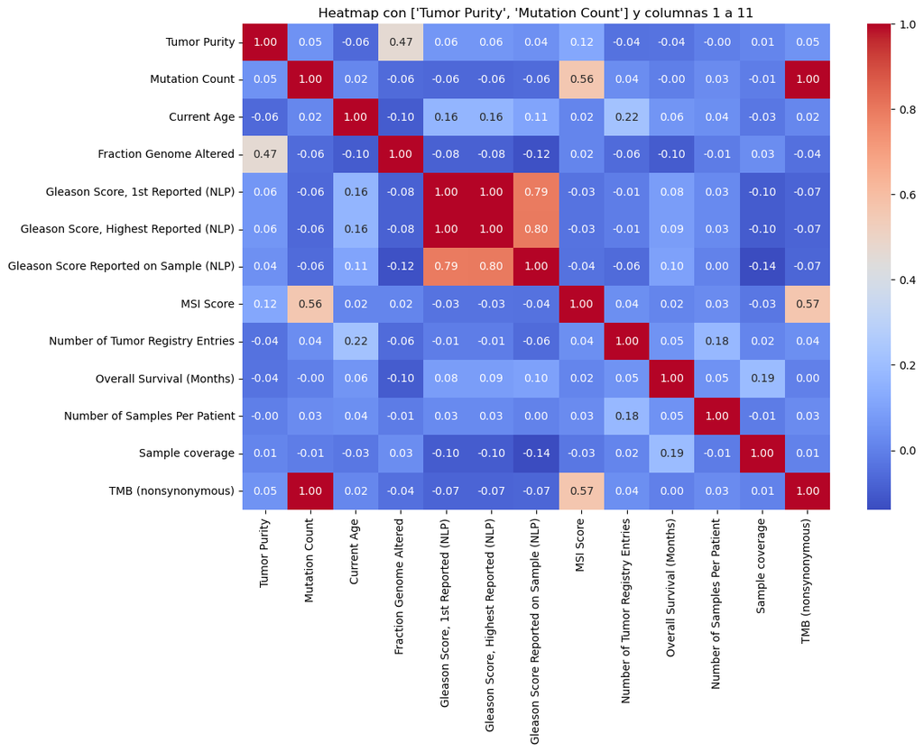

```python
# Metodo de imputación para Tumor Purity y Mutation Count, estudio de las relaciones
# Función para generar heatmaps con combinaciones de atributos numéricos
def generate_heatmaps_with_focus(data, focus_attributes, chunk_size=10):
    """
    Genera heatmaps donde siempre se incluyen ciertos atributos numéricos clave,
    combinándolos con otros atributos numéricos en bloques.

    Args:
        data (DataFrame): Dataset completo.
        focus_attributes (list): Atributos clave numéricos que deben estar siempre incluidos.
        chunk_size (int): Número de columnas adicionales por subgráfico.
    """
    # Filtrar únicamente las columnas numéricas
    numerical_columns = data.select_dtypes(include=['float64', 'int64']).columns

    # Excluir los atributos clave de las columnas restantes
    remaining_attributes = [col for col in numerical_columns if col not in focus_attributes]

    # Dividir las columnas restantes en bloques
    for i in range(0, len(remaining_attributes), chunk_size):
        # Crear un subconjunto que combine los atributos clave con el bloque actual
        subset_columns = focus_attributes + remaining_attributes[i:i + chunk_size]
        subset_data = data[subset_columns]

        # Generar el heatmap para este subconjunto de datos
        plt.figure(figsize=(12, 8))
        sns.heatmap(subset_data.corr(), annot=True, cmap='coolwarm', fmt=".2f")
        plt.title(f"Heatmap con {focus_attributes} y columnas {i+1} a {min(i + chunk_size, len(remaining_attributes))}")
        plt.show()

# Atributos clave que deben estar siempre incluidos
focus_attributes = ['Tumor Purity', 'Mutation Count']

# Llamar a la función con el dataset y tamaño de los bloques
generate_heatmaps_with_focus(data, focus_attributes=focus_attributes, chunk_size=11)
```

Se observa que Mutation Count, tiene una relación de 1 con TMB (nonsynonymous) ya que indica el número total de mutaciones. Para no duplicar la información, se decide eliminar la columna.

```python
data = data.drop(columns=['Mutation Count'])
```

```python
# Eliminar filas con valores nulos en la columna "Tumor Purity"
data = data.dropna(subset=['Tumor Purity'])

# Verificar columnas faltantes restantes tras la imputación
print("Valores faltantes por columna después de imputación:")
print(data.isnull().sum())
```

```
Valores faltantes por columna después de imputación:
Tumor Site: Adrenal Glands (NLP)             0
Tumor Site: Bone (NLP)                       0
Cancer Type                                  0
Cancer Type Detailed                         0
Tumor Site: CNS/Brain (NLP)                  0
Current Age                                  0
Diagnosis Description                        0
Ethnicity                                    0
Fraction Genome Altered                      0
Sex                                          0
Gene Panel                                   0
Gleason Score, 1st Reported (NLP)            0
Gleason Score, Highest Reported (NLP)        0
Gleason Score Reported on Sample (NLP)       0
HER2                                         0
History for Positive PD-L1 (NLP)             0
HR                                           0
ICD-O Histology Description                  0
Tumor Site: Intra Abdominal                  0
Tumor Site: Liver (NLP)                      0
Tumor Site: Lung (NLP)                       0
Tumor Site: Lymph Node (NLP)                 0
MSI Score                                    0
MSI Type                                     0
Number of Tumor Registry Entries             0
Oncotree Code                                0
Overall Survival (Months)                    0
Overall Survival Status                      0
Tumor Site: Other (NLP)                      0
Pathological Group                        6859
Sample PD-L1 Positive (NLP)                  0
Tumor Site: Pleura (NLP)                     0
Primary Tumor Site                           0
Prior Treatment to MSK (NLP)                 0
Race                                         0
Tumor Site: Reproductive Organs (NLP)        0
Number of Samples Per Patient                0
Sample coverage                              0
Sample Type                                  0
Smoking History (NLP)                        0
Somatic Status                               0
Stage (Highest Recorded)                     0
TMB (nonsynonymous)                          0
Tumor Purity                                 0
dtype: int64
```

El grupo patológio (o estadío en español) indica el tamaño del tumor con un número, y aporta informacióm adicional con la letra. Los valores nulos indican que no es posible medir el valor primario, es un valor a tener en cuenta, por lo que se mantiene.

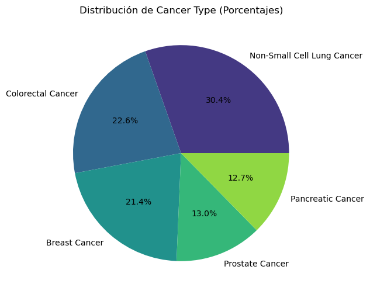

```python
import matplotlib.pyplot as plt
import seaborn as sns

# Contar la cantidad de instancias por tipo de cáncer
cancer_type_counts = data['Cancer Type'].value_counts()

# Gráfico circular
plt.figure(figsize=(6, 6))
plt.pie(cancer_type_counts.values, labels=cancer_type_counts.index, autopct='%1.1f%%', colors=sns.color_palette("viridis", len(cancer_type_counts)))
plt.title("Distribución de Cancer Type (Porcentajes)")
plt.show()
```

### 2.5- Preparación de los datos:

Se normalizan los datos numéricos, se factorizan los valores categóricos y se codifican los tipos de cáncer, pues será la variable que se utilice para los primeros modelos con división de subredes.

```python
from sklearn.preprocessing import StandardScaler
# Seleccionar columnas numéricas
numeric_columns = data.select_dtypes(include=['float64', 'int64']).columns

# Aplicar normalización (StandardScaler)
scaler = StandardScaler()
data[numeric_columns] = scaler.fit_transform(data[numeric_columns])

print("Normalización completada con StandardScaler.")
```

```
Normalización completada con StandardScaler.
```

```python
from sklearn.preprocessing import LabelEncoder

# Seleccionar columnas categóricas
categorical_columns = data.select_dtypes(include=['object']).columns

# Aplicar codificación LabelEncoder
label_encoders = {}
for col in categorical_columns:
    le = LabelEncoder()
    data[col] = le.fit_transform(data[col].astype(str))  # Convertir a string por seguridad
    label_encoders[col] = le  # Guardar el encoder para referencia futura

#Posible mejora: Usar OneHotEncoder en lugar de LabelEncoder para columnas con pocas categorías, como Tumor Site, ya que evita el problema de relaciones ordinales falsas.

# Comprobar la factorización
print("\n**Revisión de datos después de factorizar:**")
print(data.head())
```

```
**Revisión de datos después de factorizar:**
   Tumor Site: Adrenal Glands (NLP)  Tumor Site: Bone (NLP)  Cancer Type  \
2                                 0                       2            0
3                                 0                       2            2
4                                 0                       2            0
5                                 0                       2            0
6                                 0                       2            0

   Cancer Type Detailed  Tumor Site: CNS/Brain (NLP)  Current Age  \
2                    11                            2    -1.611106
3                    25                            0     0.200608
4                    11                            2    -0.980945
5                    14                            2    -1.768646
6                    11                            2    -0.902174

```

[output cut: 29 more lines]

```python
# Codificar el tipo de cáncer
le = LabelEncoder()
data['Cancer Type'] = le.fit_transform(data['Cancer Type'])

# Separar datos y variable objetivo
X = data.drop(columns=['Overall Survival Status'])
y = data['Overall Survival Status']

# Número de tipos únicos de cáncer
num_cancer_types = data['Cancer Type'].nunique()

# Dimensionalidad del embedding
embedding_dim = 8
# Cantidad de clases únicas: Si se aumenta el número de clases (por ejemplo, Cancer Type Detailed tiene 63), sería necesario incrementar el valor
```

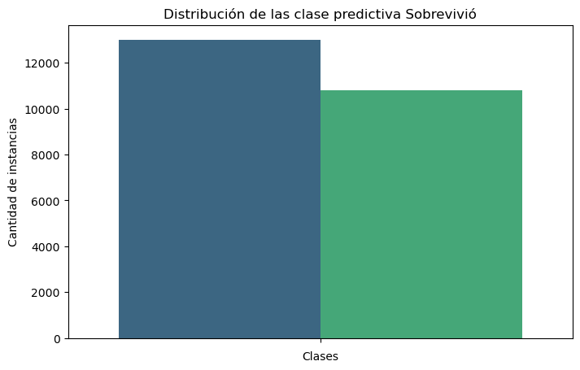

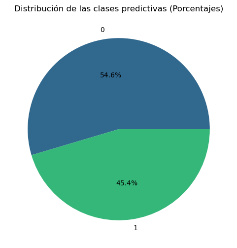

```python
# Observación de la distribución de los tipos de cáncer a predecir
# Contar la cantidad de instancias por clase
class_counts = y.value_counts()

# Crear un gráfico de barras
plt.figure(figsize=(8, 5))
sns.barplot(hue=class_counts.index, y=class_counts.values, palette="viridis",legend=False)
plt.title("Distribución de las clase predictiva Sobrevivió")
plt.xlabel("Clases")
plt.ylabel("Cantidad de instancias")
plt.show()

# Crear un gráfico circular
plt.figure(figsize=(6, 6))
plt.pie(class_counts.values, labels=class_counts.index, autopct='%1.1f%%', colors=sns.color_palette("viridis", len(class_counts)))
plt.title("Distribución de las clases predictivas (Porcentajes)")
plt.show()
```

### 2.6- Dataset final:

Se observa que las clases están bastante balanceadas, un 55% frente a un 45%. Finalmente, tenemos las siguientes columnas y siguientes valores:

```python
  # Por atributo: valores únicos y su cantidad tras EDA
  print("**Valores Únicos por Atributo:**")
  for column in data.columns:
      unique_values = data[column].unique()
      #print(f"- {column}:")
      print(f"- {column} (Tipo de dato: {data[column].dtype}):")
      print(f"  - Valores únicos: {unique_values[:5]}{'...' if len(unique_values) > 5 else ''}")
      print(f"  - Cantidad de valores únicos: {len(unique_values)}\n")
```

```
**Valores Únicos por Atributo:**
- Tumor Site: Adrenal Glands (NLP) (Tipo de dato: int32):
  - Valores únicos: [0 2 1]
  - Cantidad de valores únicos: 3

- Tumor Site: Bone (NLP) (Tipo de dato: int32):
  - Valores únicos: [2 0 1]
  - Cantidad de valores únicos: 3

- Cancer Type (Tipo de dato: int64):
  - Valores únicos: [0 2 1 4 3]
  - Cantidad de valores únicos: 5

- Cancer Type Detailed (Tipo de dato: int32):
  - Valores únicos: [11 25 14 12 30]...
  - Cantidad de valores únicos: 61

- Tumor Site: CNS/Brain (NLP) (Tipo de dato: int32):
  - Valores únicos: [2 0 1]
  - Cantidad de valores únicos: 3

- Current Age (Tipo de dato: float64):
  - Valores únicos: [-1.61110579  0.20060782 -0.98094454 -1.76864611 -0.90217438]...
  - Cantidad de valores únicos: 77

- Diagnosis Description (Tipo de dato: int32):
  - Valores únicos: [ 2  7  3 11 10]...
  - Cantidad de valores únicos: 17

- Ethnicity (Tipo de dato: int32):
  - Valores únicos: [3 1 9 7 6]...
  - Cantidad de valores únicos: 10

- Fraction Genome Altered (Tipo de dato: float64):
  - Valores únicos: [ 0.92459101 -0.87622053  1.21658516  1.34955648  1.91020697]...
  - Cantidad de valores únicos: 5875

- Sex (Tipo de dato: int32):
  - Valores únicos: [0 1]
  - Cantidad de valores únicos: 2
```

[output cut: 121 more lines]

```
- Somatic Status (Tipo de dato: int32):
  - Valores únicos: [0 1]
  - Cantidad de valores únicos: 2

- Stage (Highest Recorded) (Tipo de dato: int32):
  - Valores únicos: [0 1]
  - Cantidad de valores únicos: 2

- TMB (nonsynonymous) (Tipo de dato: float64):
  - Valores únicos: [ 0.02573378  0.22552099 -0.10745769 -0.37384064 -0.3072449 ]...
  - Cantidad de valores únicos: 423

- Tumor Purity (Tipo de dato: float64):
  - Valores únicos: [ 0.18461295 -0.33815991 -0.59954634  0.7073858  -0.86093276]...
  - Cantidad de valores únicos: 23
```

```python
def generate_heatmaps_in_chunks(data, chunk_size=11):
    """
    Genera varios heatmaps dividiendo las columnas numéricas en bloques de tamaño definido.

    Args:
        data (DataFrame): Dataset que contiene las columnas numéricas.
        chunk_size (int): Tamaño del bloque de columnas por heatmap (default: 11).
    """
    # Filtrar solo columnas numéricas
    numerical_columns = data.columns

    # Dividir las columnas numéricas en bloques
    for i in range(0, len(numerical_columns), chunk_size):
        # Seleccionar un bloque de columnas
        subset_columns = numerical_columns[i:i + chunk_size]
        subset_data = data[subset_columns]

        # Calcular la matriz de correlación para el bloque actual
        correlation_matrix = subset_data.corr()

        # Generar el heatmap para el bloque actual
        plt.figure(figsize=(10, 8))
        sns.heatmap(correlation_matrix, annot=True, cmap="coolwarm", fmt=".2f")
        plt.title(f"Heatmap de atributos {i + 1} a {min(i + chunk_size, len(numerical_columns))}")
        plt.show()
```

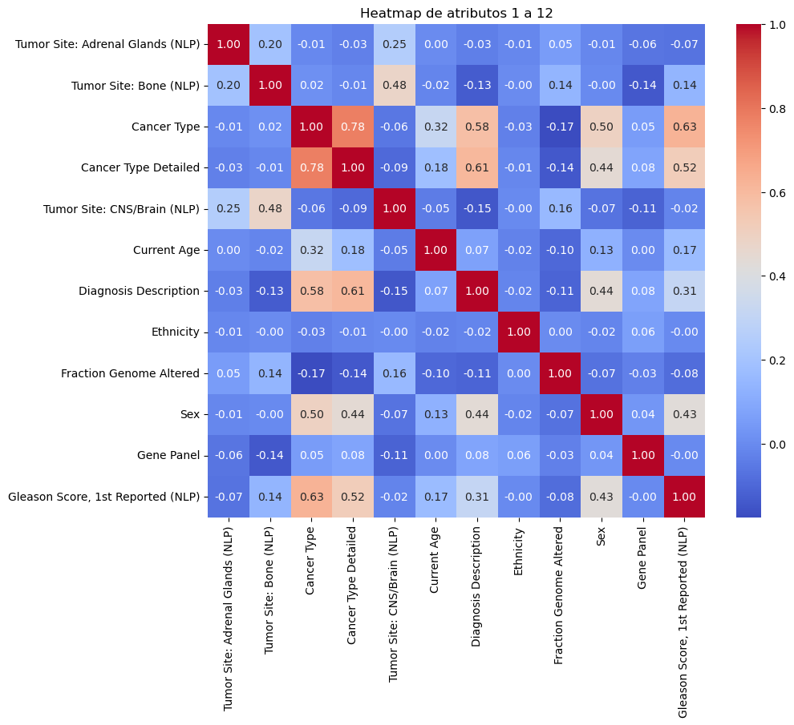

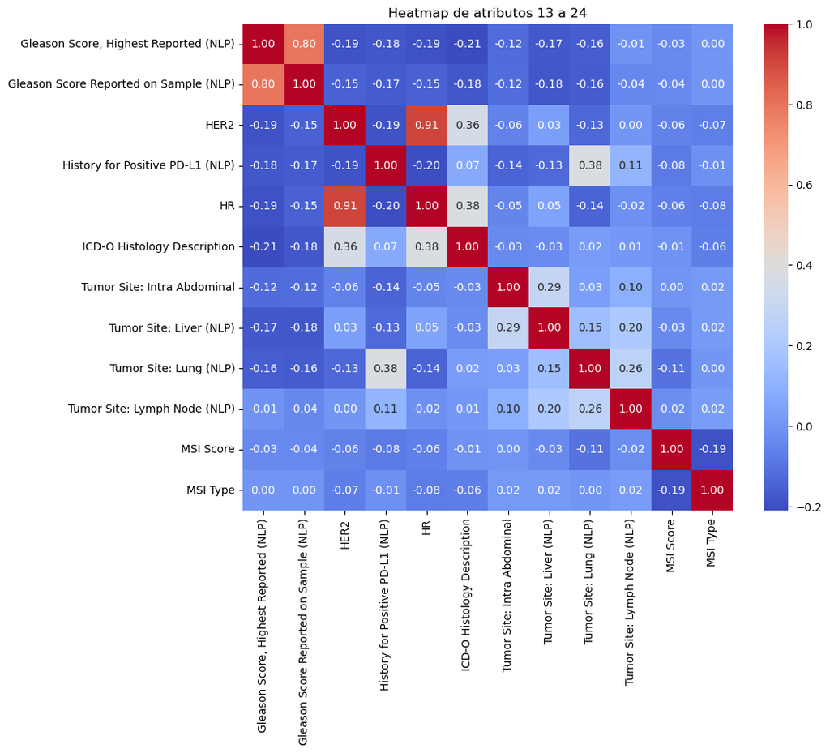

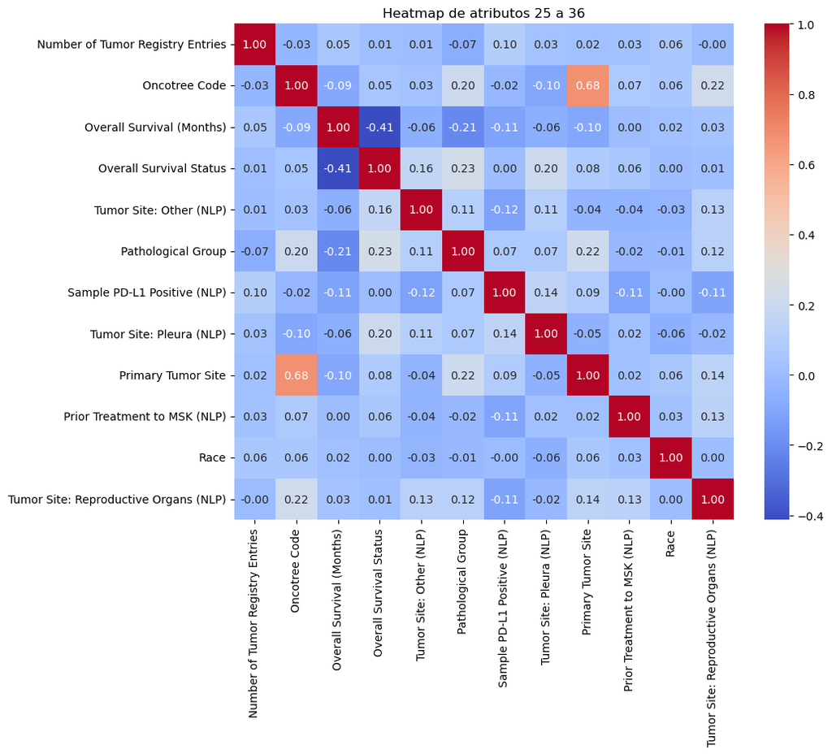

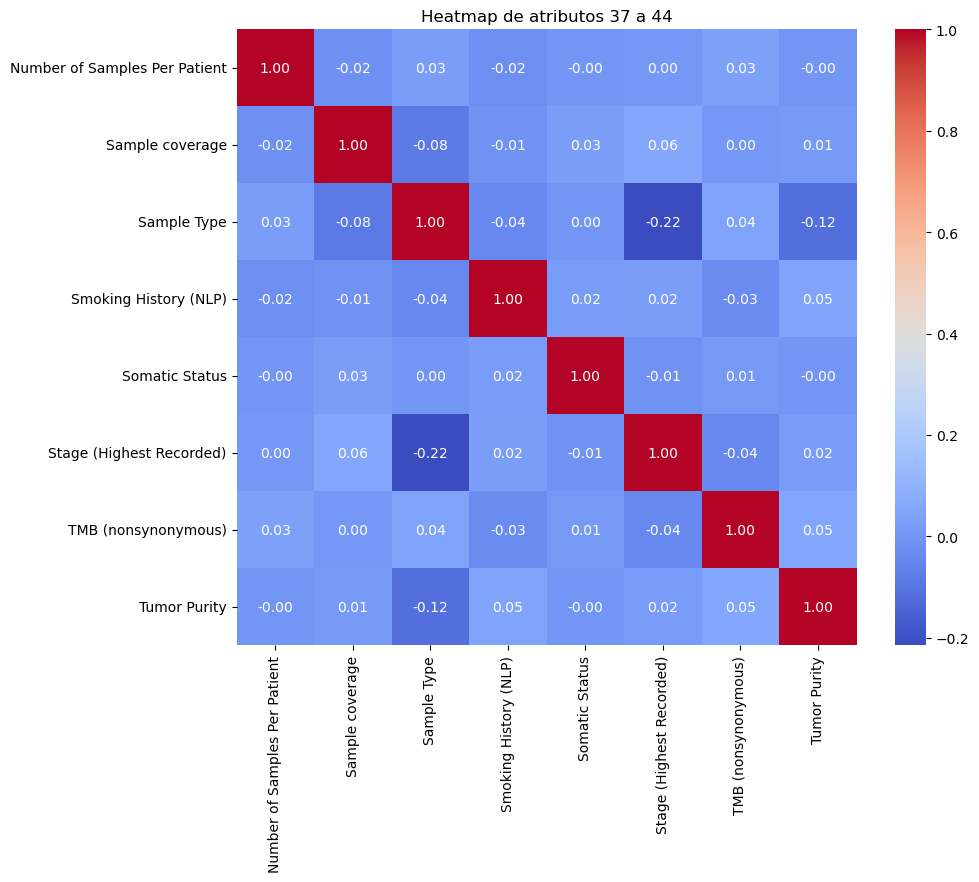

```python
# Llamar a la función con bloques de 11 columnas por heatmap
generate_heatmaps_in_chunks(data, chunk_size=12)
```

## 3- Diseño y comparativa de redes neuronales

Para diseñar una red neuronal capaz de predecir la variable Overall Survival Status (0 o 1) considerando las características del dataset, se debe seguir un enfoque estructurado que integre tanto las características específicas del Cancer Type como las generales. Por lo que se decide realizar dos aproximaciones. Una que cree diversas subredes específicas en función del tipo de cáncer y una segunda que simplemente unifique todos los atributos. Se compararán los resultados, y la que aporte mejores resultados, se optimizará con diversos algoritmos.

### 3.1- Consideraciones iniciales de estructura de los modelos

- Entrada Combinada con Subredes Específicas. Entradas Generales:

Atributos generales como Current Age, Fraction Genome Altered, Ethnicity, etc.

- Subredes para Cancer Type: Una subred dedicada para cada tipo de cáncer, que procesará las columnas específicas asociadas con ese tipo.Cada subred tendrá:

Cantidad de Neuronas en la Capa Oculta: 16 (ajustable según la complejidad del subconjunto). Función de Activación: ReLU. Estas subredes producirán salidas intermedias que se concatenarán con las características generales.

- Concatenación: Combinación de las salidas de las subredes específicas con las entradas generales en una capa completamente conectada.
- Capa Oculta Posterior a la Concatenación:Neuronas: 64, activación: ReLU, regularización: Dropout (0.2) para reducir el sobreajuste.
- Segunda Capa Oculta: neuronas: 32, activación: ReLU.
- Opcional: una tercera capa con 16 neuronas, si es necesario.
- Capa de Salida: neuronas: 1, activación: Sigmoid, para predecir la probabilidad de Overall Survival Status (0 o 1).
- Optimización y Entrenamiento

Función de Pérdida: Binary Crossentropy. Optimizador: Adam. División del Dataset: 80%-20% (entrenamiento, y validación). Métricas de Evaluación: Precisión (accuracy) y AUC-ROC.

#### Preparación del dataset para su procesamiento por el primer tipo de modelos

```python
from sklearn.model_selection import train_test_split
from imblearn.over_sampling import SMOTE
from collections import Counter

# Dividir el dataset en entrenamiento y prueba
X_train, X_test, y_train, y_test = train_test_split(X, y, test_size=0.2, random_state=42, stratify=y)

# Dividir las características en general y específicas
general_columns = [
    'Tumor Site: Adrenal Glands (NLP)', 'Tumor Site: Bone (NLP)', 'Current Age',
    'Fraction Genome Altered', 'Sex', 'Gene Panel', 'MSI Score',
    'Number of Tumor Registry Entries', 'Overall Survival (Months)',
    'Sample coverage', 'Cancer Type Detailed', 'Tumor Site: CNS/Brain (NLP)',
    'Diagnosis Description', 'Ethnicity', 'ICD-O Histology Description',
    'Tumor Site: Intra Abdominal', 'Tumor Site: Liver (NLP)', 'Tumor Site: Lung (NLP)',
    'Tumor Site: Lymph Node (NLP)', 'MSI Score', 'MSI Type', 'Oncotree Code',
    'Tumor Site: Other (NLP)', 'Pathological Group', 'Tumor Site: Pleura (NLP)',
    'Primary Tumor Site', 'Prior Treatment to MSK (NLP)', 'Race',
    'Tumor Site: Reproductive Organs (NLP)', 'Number of Samples Per Patient',
    'Sample coverage', 'Sample Type', 'Smoking History (NLP)', 'Somatic Status',
    'Stage (Highest Recorded)', 'TMB (nonsynonymous)', 'Tumor Purity'
]

breast_cancer_cols = ['HER2', 'HR']
lung_cancer_cols = ['History for Positive PD-L1 (NLP)', 'Sample PD-L1 Positive (NLP)']
prostate_cancer_cols = [
    'Gleason Score, 1st Reported (NLP)', 'Gleason Score, Highest Reported (NLP)',
    'Gleason Score Reported on Sample (NLP)'
]
############# Disminuye la precisión un 1% al balancear las variblaes
# Aplicar SMOTE para balancear las clases en el conjunto de entrenamiento
#smote = SMOTE(random_state=42)
#X_train_balanced, y_train_balanced = smote.fit_resample(X_train, y_train)
#X_train=X_train_balanced
#y_train=y_train_balanced

# Verificar el balance de clases antes y después de SMOTE
#print("\nDistribución de clases antes de SMOTE:", Counter(y_train))
#print("Distribución de clases después de SMOTE:", Counter(y_train_balanced))

# Separar las columnas generales y específicas para entrenamiento y prueba
X_train_general = X_train[general_columns]
X_test_general = X_test[general_columns]

X_train_cancer_type = X_train[['Cancer Type']]
X_test_cancer_type = X_test[['Cancer Type']]

X_train_breast = X_train[breast_cancer_cols]
X_test_breast = X_test[breast_cancer_cols]

X_train_lung = X_train[lung_cancer_cols]
X_test_lung = X_test[lung_cancer_cols]

X_train_prostate = X_train[prostate_cancer_cols]
X_test_prostate = X_test[prostate_cancer_cols]

print("Inputs:", X_train.shape)
print("General Features Shape:", X_train_general.shape)
print("Cancer Type Shape:", X_train_cancer_type.shape)
print("Breast Cancer Features Shape:", X_train_breast.shape)
print("Lung Cancer Features Shape:", X_train_lung.shape)
print("Prostate Cancer Features Shape:", X_train_prostate.shape)
```

```
Inputs: (19046, 43)
General Features Shape: (19046, 37)
Cancer Type Shape: (19046, 1)
Breast Cancer Features Shape: (19046, 2)
Lung Cancer Features Shape: (19046, 2)
Prostate Cancer Features Shape: (19046, 3)
```

Empezamos con la importación de librerias

```python
# Librerías principales
import tensorflow as tf
from tensorflow.keras.models import Model
from tensorflow.keras.layers import Input, Dense, Dropout, Flatten, Embedding, BatchNormalization, concatenate, Concatenate
from sklearn.model_selection import train_test_split
from sklearn.metrics import confusion_matrix, roc_curve, roc_auc_score, classification_report
import seaborn as sns
import matplotlib.pyplot as plt
import numpy as np
from sklearn.metrics import confusion_matrix, classification_report
from sklearn.model_selection import KFold
from sklearn.metrics import accuracy_score, roc_auc_score
```

Estas son las funciones de evaluación para utilizar en las comparativas:

```python
# Evaluar el modelo
def plot_training_history(history):
    """
    Genera gráficos para analizar la precisión y el error del modelo durante el entrenamiento y la validación.

    Args:
        history: Objeto History de Keras generado durante el entrenamiento.
    """
    # Precisión (accuracy)
    plt.figure(figsize=(12, 5))
    plt.subplot(1, 2, 1)
    plt.plot(history.history['accuracy'], label='Precisión de entrenamiento')
    plt.plot(history.history['val_accuracy'], label='Precisión de validación')
    plt.title('Precisión durante el entrenamiento')
    plt.xlabel('Épocas')
    plt.ylabel('Precisión')
    plt.legend()

    # Error (pérdida)
    plt.subplot(1, 2, 2)
    plt.plot(history.history['loss'], label='Pérdida de entrenamiento')
    plt.plot(history.history['val_loss'], label='Pérdida de validación')
    plt.title('Pérdida durante el entrenamiento')
    plt.xlabel('Épocas')
    plt.ylabel('Pérdida')
    plt.legend()

    plt.tight_layout()
    plt.show()
```

```python
# Función para matriz de confusión
def plot_confusion_matrix_and_metrics(y_true, y_pred):
    """
    Genera una matriz de confusión y calcula métricas como TP, TN, FP, FN,
    precision, recall y F1-score.

    Args:
        y_true: Array de valores reales (etiquetas).
        y_pred: Array de valores predichos por el modelo (probabilidades o clases).
    """
    # Binarizar predicciones (umbral 0.5)
    y_pred_binarized = (y_pred > 0.5).astype(int)

    # Matriz de confusión
    cm = confusion_matrix(y_true, y_pred_binarized)
    tn, fp, fn, tp = cm.ravel()

    # Mostrar métricas TP, TN, FP, FN
    print("Verdaderos Negativos (TN):", tn)
    print("Falsos Positivos (FP):", fp)
    print("Falsos Negativos (FN):", fn)
    print("Verdaderos Positivos (TP):", tp)

    # Calcular y mostrar métricas adicionales
    print("\nClasificación detallada:")
    print(classification_report(y_true, y_pred_binarized))

    # Graficar la matriz de confusión
    plt.figure(figsize=(8, 6))
    sns.heatmap(cm, annot=True, fmt="d", cmap="Blues", xticklabels=["Negativo", "Positivo"], yticklabels=["Negativo", "Positivo"])
    plt.title("Matriz de Confusión")
    plt.xlabel("Predicciones")
    plt.ylabel("Valores Reales")
    plt.show()
```

```python
def plot_auc_roc(y_true, y_pred, model_name="Modelo"):
    """
    Genera la curva AUC-ROC para un modelo.

    Args:
        y_true: Etiquetas reales.
        y_pred: Predicciones probabilísticas.
        model_name: Nombre del modelo para el gráfico.
    """
    fpr, tpr, _ = roc_curve(y_true, y_pred)
    auc_score = roc_auc_score(y_true, y_pred)

    plt.figure(figsize=(8, 6))
    plt.plot(fpr, tpr, label=f"AUC = {auc_score:.2f}")
    plt.plot([0, 1], [0, 1], "k--", label="Aleatorio")
    plt.title(f"Curva AUC-ROC ({model_name})")
    plt.xlabel("FPR (Tasa de Falsos Positivos)")
    plt.ylabel("TPR (Tasa de Verdaderos Positivos)")
    plt.legend()
    plt.grid()
    plt.show()
```

Preparar los datos para su división:

```python
# Dividir el dataset en entrenamiento y prueba
X_train, X_test, y_train, y_test = train_test_split(X, y, test_size=0.2, random_state=42, stratify=y)

# Definir las columnas generales y específicas
general_columns = [
    'Tumor Site: Adrenal Glands (NLP)', 'Tumor Site: Bone (NLP)', 'Current Age',
    'Fraction Genome Altered', 'Sex', 'Gene Panel', 'MSI Score',
    'Number of Tumor Registry Entries', 'Overall Survival (Months)',
    'Sample coverage', 'Cancer Type Detailed', 'Tumor Site: CNS/Brain (NLP)',
    'Diagnosis Description', 'Ethnicity', 'ICD-O Histology Description',
    'Tumor Site: Intra Abdominal', 'Tumor Site: Liver (NLP)', 'Tumor Site: Lung (NLP)',
    'Tumor Site: Lymph Node (NLP)', 'MSI Score', 'MSI Type', 'Oncotree Code',
    'Tumor Site: Other (NLP)', 'Pathological Group', 'Tumor Site: Pleura (NLP)',
    'Primary Tumor Site', 'Prior Treatment to MSK (NLP)', 'Race',
    'Tumor Site: Reproductive Organs (NLP)', 'Number of Samples Per Patient',
    'Sample coverage', 'Sample Type', 'Smoking History (NLP)', 'Somatic Status',
    'Stage (Highest Recorded)', 'TMB (nonsynonymous)', 'Tumor Purity'
]

breast_cancer_cols = ['HER2', 'HR']
lung_cancer_cols = ['History for Positive PD-L1 (NLP)', 'Sample PD-L1 Positive (NLP)']
prostate_cancer_cols = [
    'Gleason Score, 1st Reported (NLP)', 'Gleason Score, Highest Reported (NLP)',
    'Gleason Score Reported on Sample (NLP)'
]

# Separar las características generales y específicas para entrenamiento y prueba
X_train_general = X_train[general_columns]
X_test_general = X_test[general_columns]

X_train_cancer_type = X_train[['Cancer Type']]
X_test_cancer_type = X_test[['Cancer Type']]

X_train_breast = X_train[breast_cancer_cols]
X_test_breast = X_test[breast_cancer_cols]

X_train_lung = X_train[lung_cancer_cols]
X_test_lung = X_test[lung_cancer_cols]

X_train_prostate = X_train[prostate_cancer_cols]
X_test_prostate = X_test[prostate_cancer_cols]

print("Entrenamiento general:", X_train_general.shape)
print("Entrenamiento cáncer tipo:", X_train_cancer_type.shape)
print("Entrenamiento cáncer mama:", X_train_breast.shape)
```

```
Entrenamiento general: (19046, 37)
Entrenamiento cáncer tipo: (19046, 1)
Entrenamiento cáncer mama: (19046, 2)
```

### 3.2- Creación de los primeros modelos:

Modelos con división de subredes específicas por tipo de cáncer.

```python
import tensorflow as tf
# Learning rate
lr=0.0001

# Early Stopping
early_stop = tf.keras.callbacks.EarlyStopping(monitor='val_loss', patience=50, restore_best_weights=True) # patience alto para que se vean mejores gráficas
```

```python
# Primer modelo: Red sin tercera capa
from tensorflow.keras.models import Model
from tensorflow.keras.layers import Input, Dense, Dropout, concatenate, Embedding, Flatten

# Definición de parámetros
breast_cancer_cols = ['HER2', 'HR']
lung_cancer_cols = ['History for Positive PD-L1 (NLP)', 'Sample PD-L1 Positive (NLP)']
prostate_cancer_cols = [
    'Gleason Score, 1st Reported (NLP)', 'Gleason Score, Highest Reported (NLP)',
    'Gleason Score Reported on Sample (NLP)'
]

# Entrada general
general_input = Input(shape=(37,), name="General_Input")

# Embedding para Cancer Type
cancer_type_input = Input(shape=(1,), name="Cancer_Type_Input")
cancer_type_embedding = Embedding(input_dim=num_cancer_types, output_dim=embedding_dim, name="Cancer_Type_Embedding")(cancer_type_input)
cancer_type_flat = Flatten(name="Flatten_Cancer_Type")(cancer_type_embedding)

# Subredes específicas
breast_input = Input(shape=(len(breast_cancer_cols),), name="Breast_Input")
breast_hidden = Dense(16, activation="relu", name="Breast_Hidden")(breast_input)

lung_input = Input(shape=(len(lung_cancer_cols),), name="Lung_Input")
lung_hidden = Dense(16, activation="relu", name="Lung_Hidden")(lung_input)

prostate_input = Input(shape=(len(prostate_cancer_cols),), name="Prostate_Input")
prostate_hidden = Dense(16, activation="relu", name="Prostate_Hidden")(prostate_input)

# Concatenación
merged = concatenate([general_input, cancer_type_flat, breast_hidden, lung_hidden, prostate_hidden], name="Concatenate_Layer")

# Capas ocultas generales
hidden_1 = Dense(64, activation="relu", name="Hidden_Layer_1")(merged)
dropout_1 = Dropout(0.2, name="Dropout_1")(hidden_1)
hidden_2 = Dense(32, activation="relu", name="Hidden_Layer_2")(dropout_1)

# Capa de salida
output = Dense(1, activation="sigmoid", name="Output")(hidden_2)

# Construir modelo
model_no_third = Model(inputs=[general_input, cancer_type_input, breast_input, lung_input, prostate_input], outputs=output, name="Modelo_de_dos_capas_ocultas_con_division_en_subredes_por_tipo_de_cancer")

# Compilar modelo
model_no_third.compile(tf.keras.optimizers.Adam(learning_rate=lr), loss="binary_crossentropy", metrics=["accuracy"])
model_no_third.summary()
```

```
Model: "Modelo_de_dos_capas_ocultas_con_division_en_subredes_por_tipo_de_cancer"
```

```
┏━━━━━━━━━━━━━━━━━━━━━┳━━━━━━━━━━━━━━━━━━━┳━━━━━━━━━━━━┳━━━━━━━━━━━━━━━━━━━┓
┃ Layer (type)        ┃ Output Shape      ┃    Param # ┃ Connected to      ┃
┡━━━━━━━━━━━━━━━━━━━━━╇━━━━━━━━━━━━━━━━━━━╇━━━━━━━━━━━━╇━━━━━━━━━━━━━━━━━━━┩
│ Cancer_Type_Input   │ (None, 1)         │          0 │ -                 │
│ (InputLayer)        │                   │            │                   │
├─────────────────────┼───────────────────┼────────────┼───────────────────┤
│ Cancer_Type_Embedd… │ (None, 1, 8)      │         40 │ Cancer_Type_Inpu… │
│ (Embedding)         │                   │            │                   │
├─────────────────────┼───────────────────┼────────────┼───────────────────┤
│ Breast_Input        │ (None, 2)         │          0 │ -                 │
│ (InputLayer)        │                   │            │                   │
├─────────────────────┼───────────────────┼────────────┼───────────────────┤
│ Lung_Input          │ (None, 2)         │          0 │ -                 │
│ (InputLayer)        │                   │            │                   │
├─────────────────────┼───────────────────┼────────────┼───────────────────┤
│ Prostate_Input      │ (None, 3)         │          0 │ -                 │
│ (InputLayer)        │                   │            │                   │
├─────────────────────┼───────────────────┼────────────┼───────────────────┤
│ General_Input       │ (None, 37)        │          0 │ -                 │
│ (InputLayer)        │                   │            │                   │
├─────────────────────┼───────────────────┼────────────┼───────────────────┤
│ Flatten_Cancer_Type │ (None, 8)         │          0 │ Cancer_Type_Embe… │
│ (Flatten)           │                   │            │                   │
├─────────────────────┼───────────────────┼────────────┼───────────────────┤
│ Breast_Hidden       │ (None, 16)        │         48 │ Breast_Input[0][… │
│ (Dense)             │                   │            │                   │
├─────────────────────┼───────────────────┼────────────┼───────────────────┤
│ Lung_Hidden (Dense) │ (None, 16)        │         48 │ Lung_Input[0][0]  │
├─────────────────────┼───────────────────┼────────────┼───────────────────┤
│ Prostate_Hidden     │ (None, 16)        │         64 │ Prostate_Input[0… │
│ (Dense)             │                   │            │                   │
├─────────────────────┼───────────────────┼────────────┼───────────────────┤
│ Concatenate_Layer   │ (None, 93)        │          0 │ General_Input[0]… │
│ (Concatenate)       │                   │            │ Flatten_Cancer_T… │
│                     │                   │            │ Breast_Hidden[0]… │
│                     │                   │            │ Lung_Hidden[0][0… │
│                     │                   │            │ Prostate_Hidden[… │
├─────────────────────┼───────────────────┼────────────┼───────────────────┤
│ Hidden_Layer_1      │ (None, 64)        │      6,016 │ Concatenate_Laye… │
│ (Dense)             │                   │            │                   │
├─────────────────────┼───────────────────┼────────────┼───────────────────┤
│ Dropout_1 (Dropout) │ (None, 64)        │          0 │ Hidden_Layer_1[0… │
├─────────────────────┼───────────────────┼────────────┼───────────────────┤
│ Hidden_Layer_2      │ (None, 32)        │      2,080 │ Dropout_1[0][0]   │
│ (Dense)             │                   │            │                   │
├─────────────────────┼───────────────────┼────────────┼───────────────────┤
│ Output (Dense)      │ (None, 1)         │         33 │ Hidden_Layer_2[0… │
└─────────────────────┴───────────────────┴────────────┴───────────────────┘
```

```
 Total params: 8,329 (32.54 KB)
```

```
 Trainable params: 8,329 (32.54 KB)
```

```
 Non-trainable params: 0 (0.00 B)
```

```python
# Segundo modelo: Red con tercera capa
# Capa adicional oculta
hidden_3 = Dense(16, activation="relu", name="Hidden_Layer_3")(hidden_2)
dropout_2 = Dropout(0.2, name="Dropout_2")(hidden_3)

# Capa de salida
output_with_third = Dense(1, activation="sigmoid", name="Output")(dropout_2)

# Construir modelo
model_with_third = Model(inputs=[general_input, cancer_type_input, breast_input, lung_input, prostate_input], outputs=output_with_third, name="Modelo_de_tres_capas_ocultas_con_division_en_subredes_por_tipo_de_cancer")

# Compilar modelo
model_with_third.compile(tf.keras.optimizers.Adam(learning_rate=lr), loss="binary_crossentropy", metrics=["accuracy"])
model_with_third.summary()
```

```
Model: "Modelo_de_tres_capas_ocultas_con_division_en_subredes_por_tipo_de_cancer"
```

```
┏━━━━━━━━━━━━━━━━━━━━━┳━━━━━━━━━━━━━━━━━━━┳━━━━━━━━━━━━┳━━━━━━━━━━━━━━━━━━━┓
┃ Layer (type)        ┃ Output Shape      ┃    Param # ┃ Connected to      ┃
┡━━━━━━━━━━━━━━━━━━━━━╇━━━━━━━━━━━━━━━━━━━╇━━━━━━━━━━━━╇━━━━━━━━━━━━━━━━━━━┩
│ Cancer_Type_Input   │ (None, 1)         │          0 │ -                 │
│ (InputLayer)        │                   │            │                   │
├─────────────────────┼───────────────────┼────────────┼───────────────────┤
│ Cancer_Type_Embedd… │ (None, 1, 8)      │         40 │ Cancer_Type_Inpu… │
│ (Embedding)         │                   │            │                   │
├─────────────────────┼───────────────────┼────────────┼───────────────────┤
│ Breast_Input        │ (None, 2)         │          0 │ -                 │
│ (InputLayer)        │                   │            │                   │
├─────────────────────┼───────────────────┼────────────┼───────────────────┤
│ Lung_Input          │ (None, 2)         │          0 │ -                 │
│ (InputLayer)        │                   │            │                   │
├─────────────────────┼───────────────────┼────────────┼───────────────────┤
│ Prostate_Input      │ (None, 3)         │          0 │ -                 │
│ (InputLayer)        │                   │            │                   │
├─────────────────────┼───────────────────┼────────────┼───────────────────┤
│ General_Input       │ (None, 37)        │          0 │ -                 │
│ (InputLayer)        │                   │            │                   │
├─────────────────────┼───────────────────┼────────────┼───────────────────┤
│ Flatten_Cancer_Type │ (None, 8)         │          0 │ Cancer_Type_Embe… │
│ (Flatten)           │                   │            │                   │
├─────────────────────┼───────────────────┼────────────┼───────────────────┤
│ Breast_Hidden       │ (None, 16)        │         48 │ Breast_Input[0][… │
│ (Dense)             │                   │            │                   │
├─────────────────────┼───────────────────┼────────────┼───────────────────┤
│ Lung_Hidden (Dense) │ (None, 16)        │         48 │ Lung_Input[0][0]  │
├─────────────────────┼───────────────────┼────────────┼───────────────────┤
│ Prostate_Hidden     │ (None, 16)        │         64 │ Prostate_Input[0… │
│ (Dense)             │                   │            │                   │
├─────────────────────┼───────────────────┼────────────┼───────────────────┤
│ Concatenate_Layer   │ (None, 93)        │          0 │ General_Input[0]… │
│ (Concatenate)       │                   │            │ Flatten_Cancer_T… │
│                     │                   │            │ Breast_Hidden[0]… │
│                     │                   │            │ Lung_Hidden[0][0… │
│                     │                   │            │ Prostate_Hidden[… │
├─────────────────────┼───────────────────┼────────────┼───────────────────┤
│ Hidden_Layer_1      │ (None, 64)        │      6,016 │ Concatenate_Laye… │
│ (Dense)             │                   │            │                   │
├─────────────────────┼───────────────────┼────────────┼───────────────────┤
│ Dropout_1 (Dropout) │ (None, 64)        │          0 │ Hidden_Layer_1[0… │
├─────────────────────┼───────────────────┼────────────┼───────────────────┤
│ Hidden_Layer_2      │ (None, 32)        │      2,080 │ Dropout_1[0][0]   │
│ (Dense)             │                   │            │                   │
├─────────────────────┼───────────────────┼────────────┼───────────────────┤
│ Hidden_Layer_3      │ (None, 16)        │        528 │ Hidden_Layer_2[0… │
│ (Dense)             │                   │            │                   │
├─────────────────────┼───────────────────┼────────────┼───────────────────┤
│ Dropout_2 (Dropout) │ (None, 16)        │          0 │ Hidden_Layer_3[0… │
├─────────────────────┼───────────────────┼────────────┼───────────────────┤
│ Output (Dense)      │ (None, 1)         │         17 │ Dropout_2[0][0]   │
└─────────────────────┴───────────────────┴────────────┴───────────────────┘
```

```
 Total params: 8,841 (34.54 KB)
```

```
 Trainable params: 8,841 (34.54 KB)
```

```
 Non-trainable params: 0 (0.00 B)
```

Para tener una mayor consistencia en los resultados, se aplica validación cruzada

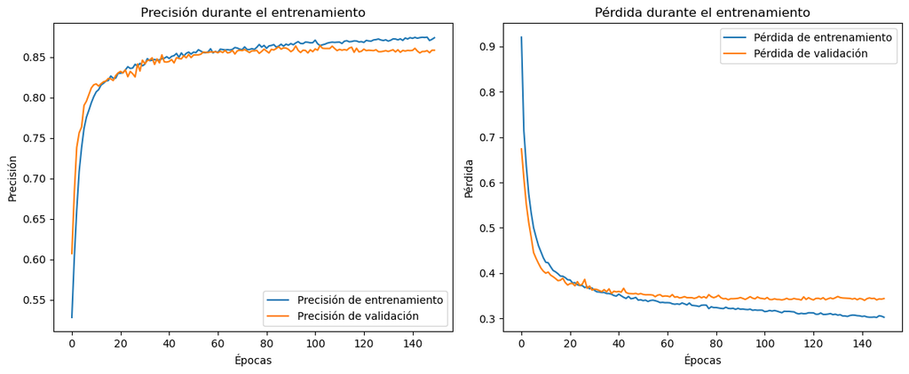

```
120/120 ━━━━━━━━━━━━━━━━━━━━ 0s 1ms/step
120/120 ━━━━━━━━━━━━━━━━━━━━ 0s 689us/step
120/120 ━━━━━━━━━━━━━━━━━━━━ 0s 689us/step
120/120 ━━━━━━━━━━━━━━━━━━━━ 0s 689us/step
120/120 ━━━━━━━━━━━━━━━━━━━━ 0s 739us/step
Precisión promedio de aprendizaje en validación cruzada sin tercera capa: 0.8759
AUC-ROC promedio de aprendizaje en validación cruzada sin tercera capa: 0.9442
149/149 ━━━━━━━━━━━━━━━━━━━━ 0s 757us/step - accuracy: 0.8563 - loss: 0.3463

Valores de evaluación del modelo 1: Red sin tercera capa - Pérdida: 0.3435, Precisión: 85.6783%
```

```python
# Definir validación cruzada con KFold
kf = KFold(n_splits=5, shuffle=True, random_state=42)  # 5 pliegues

# Listas para almacenar resultados
accuracy_scores = []
auc_scores = []

#print(type(X_train_cancer_type))

# Contador de iteraciones
first_iteration = True

# Validación cruzada
for train_index, val_index in kf.split(X_train_general):
    # Para DataFrame de Pandas (usar .iloc)
    X_train_fold_general = X_train_general.iloc[train_index]
    X_val_fold_general = X_train_general.iloc[val_index]
    X_train_fold_cancer = X_train_cancer_type.iloc[train_index]
    X_val_fold_cancer = X_train_cancer_type.iloc[val_index]

    # Para Series de Pandas (usar .iloc)
    y_train_fold = y_train.iloc[train_index]
    y_val_fold = y_train.iloc[val_index]

    # Ajustar más conjuntos según el tipo si hay otros
    X_train_fold_breast = X_train_breast.iloc[train_index] if isinstance(X_train_breast, pd.DataFrame) else X_train_breast[train_index]
    X_val_fold_breast = X_train_breast.iloc[val_index] if isinstance(X_train_breast, pd.DataFrame) else X_train_breast[val_index]

    X_train_fold_lung = X_train_lung.iloc[train_index] if isinstance(X_train_lung, pd.DataFrame) else X_train_lung[train_index]
    X_val_fold_lung = X_train_lung.iloc[val_index] if isinstance(X_train_lung, pd.DataFrame) else X_train_lung[val_index]

    X_train_fold_prostate = X_train_prostate.iloc[train_index] if isinstance(X_train_prostate, pd.DataFrame) else X_train_prostate[train_index]
    X_val_fold_prostate = X_train_prostate.iloc[val_index] if isinstance(X_train_prostate, pd.DataFrame) else X_train_prostate[val_index]

    # Entrenamiento y evaluación con la red neuronal sin tercera capa
    history_no_third = model_no_third.fit(
        [X_train_fold_general, X_train_fold_cancer, X_train_fold_breast, X_train_fold_lung, X_train_fold_prostate],
        y_train_fold,
        validation_data=([X_val_fold_general, X_val_fold_cancer, X_val_fold_breast, X_val_fold_lung, X_val_fold_prostate], y_val_fold),
        epochs=150,
        batch_size=32,
        callbacks=[early_stop],
        verbose=0
    )

    if first_iteration: # Mostrar primera funcion de entrenamiento
        plot_training_history(history_no_third)
        first_iteration = False  # Cambiar a False para no volver a mostrarla

    y_val_pred = model_no_third.predict([X_val_fold_general, X_val_fold_cancer, X_val_fold_breast, X_val_fold_lung, X_val_fold_prostate])
    y_val_pred_binary = (y_val_pred > 0.5).astype(int)

    accuracy = accuracy_score(y_val_fold, y_val_pred_binary)
    auc = roc_auc_score(y_val_fold, y_val_pred)
    accuracy_scores.append(accuracy)
    auc_scores.append(auc)

# Resultados del entrenamiento con validación cruzada
mean_accuracy_no_third = sum(accuracy_scores) / len(accuracy_scores)
mean_auc_no_third = sum(auc_scores) / len(auc_scores)
print(f"Precisión promedio de aprendizaje en validación cruzada sin tercera capa: {mean_accuracy_no_third:.4f}")
print(f"AUC-ROC promedio de aprendizaje en validación cruzada sin tercera capa: {mean_auc_no_third:.4f}")

# Evaluación final del modelo sin tercera capa
loss_no_third, accuracy_no_third = model_no_third.evaluate(
    [X_test_general, X_test_cancer_type, X_test_breast, X_test_lung, X_test_prostate],
    y_test
)
print(f"\nValores de evaluación del modelo 1: Red sin tercera capa - Pérdida: {loss_no_third:.4f}, Precisión: {accuracy_no_third:.4%}")
```

```
149/149 ━━━━━━━━━━━━━━━━━━━━ 0s 689us/step
Verdaderos Negativos (TN): 2265
Falsos Positivos (FP): 335
Falsos Negativos (FN): 347
Verdaderos Positivos (TP): 1815

Clasificación detallada:
              precision    recall  f1-score   support

           0       0.87      0.87      0.87      2600
           1       0.84      0.84      0.84      2162

    accuracy                           0.86      4762
   macro avg       0.86      0.86      0.86      4762
weighted avg       0.86      0.86      0.86      4762
```

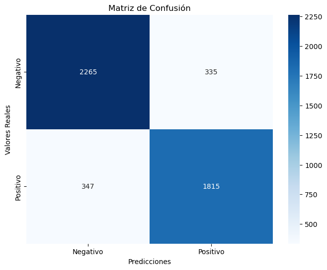

```
149/149 ━━━━━━━━━━━━━━━━━━━━ 0s 696us/step
```

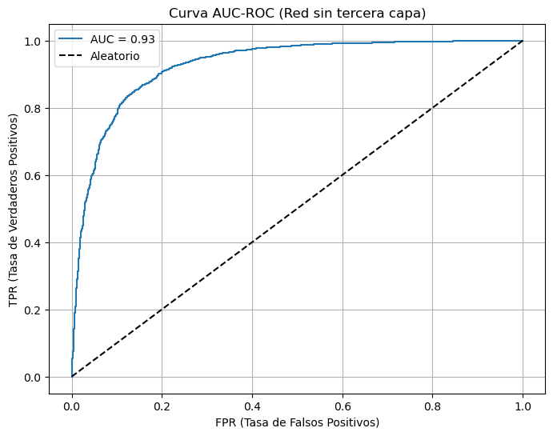

```python
# Visualización de resultados
#plot_training_history(history_no_third)
plot_confusion_matrix_and_metrics(y_test, model_no_third.predict(
    [X_test_general, X_test_cancer_type, X_test_breast, X_test_lung, X_test_prostate]))
plot_auc_roc(y_test, model_no_third.predict(
    [X_test_general, X_test_cancer_type, X_test_breast, X_test_lung, X_test_prostate]), model_name="Red sin tercera capa")
```

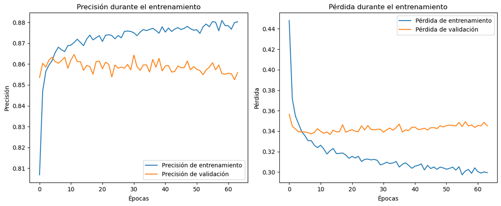

```
120/120 ━━━━━━━━━━━━━━━━━━━━ 0s 1ms/step
120/120 ━━━━━━━━━━━━━━━━━━━━ 0s 773us/step
120/120 ━━━━━━━━━━━━━━━━━━━━ 0s 697us/step
120/120 ━━━━━━━━━━━━━━━━━━━━ 0s 689us/step
120/120 ━━━━━━━━━━━━━━━━━━━━ 0s 756us/step
Precisión promedio de aprendizaje en validación cruzada con tercera capa: 0.8758
AUC-ROC promedio de aprendizaje en validación cruzada con tercera capa: 0.9431
149/149 ━━━━━━━━━━━━━━━━━━━━ 0s 784us/step - accuracy: 0.8545 - loss: 0.3442

Valores de evaluación del modelo 2: Red con tercera capa - Pérdida: 0.3441, Precisión: 85.3213%
```

```python
#Entrenamiento para el segundo modelo
#Inicializamos listas para almacenar los valores a promediar
accuracy_scores = []
auc_scores = []

# Contador de iteraciones
first_iteration = True

# Validación cruzada
for train_index, val_index in kf.split(X_train_general):
    # Para DataFrame de Pandas (usar .iloc)
    X_train_fold_general = X_train_general.iloc[train_index]
    X_val_fold_general = X_train_general.iloc[val_index]
    X_train_fold_cancer = X_train_cancer_type.iloc[train_index]
    X_val_fold_cancer = X_train_cancer_type.iloc[val_index]

    # Para Series de Pandas (usar .iloc)
    y_train_fold = y_train.iloc[train_index]
    y_val_fold = y_train.iloc[val_index]

    # Ajustar más conjuntos según el tipo si hay otros
    X_train_fold_breast = X_train_breast.iloc[train_index] if isinstance(X_train_breast, pd.DataFrame) else X_train_breast[train_index]
    X_val_fold_breast = X_train_breast.iloc[val_index] if isinstance(X_train_breast, pd.DataFrame) else X_train_breast[val_index]

    X_train_fold_lung = X_train_lung.iloc[train_index] if isinstance(X_train_lung, pd.DataFrame) else X_train_lung[train_index]
    X_val_fold_lung = X_train_lung.iloc[val_index] if isinstance(X_train_lung, pd.DataFrame) else X_train_lung[val_index]

    X_train_fold_prostate = X_train_prostate.iloc[train_index] if isinstance(X_train_prostate, pd.DataFrame) else X_train_prostate[train_index]
    X_val_fold_prostate = X_train_prostate.iloc[val_index] if isinstance(X_train_prostate, pd.DataFrame) else X_train_prostate[val_index]

    # Entrenamiento y evaluación con la red neuronal con tercera capa
    history_with_third = model_with_third.fit(
        [X_train_fold_general, X_train_fold_cancer, X_train_fold_breast, X_train_fold_lung, X_train_fold_prostate],
        y_train_fold,
        validation_data=([X_val_fold_general, X_val_fold_cancer, X_val_fold_breast, X_val_fold_lung, X_val_fold_prostate], y_val_fold),
        epochs=150,
        batch_size=32,
        callbacks=[early_stop],
        verbose=0
    )
    if first_iteration: # Mostrar primera funcion de entrenamiento
        plot_training_history(history_with_third)
        first_iteration = False  # Cambiar a False para no volver a mostrarla


    y_val_pred = model_with_third.predict([X_val_fold_general, X_val_fold_cancer, X_val_fold_breast, X_val_fold_lung, X_val_fold_prostate])
    y_val_pred_binary = (y_val_pred > 0.5).astype(int)

    accuracy = accuracy_score(y_val_fold, y_val_pred_binary)
    auc = roc_auc_score(y_val_fold, y_val_pred)
    accuracy_scores.append(accuracy)
    auc_scores.append(auc)

# Resultados de aprendizaje con validación cruzada
mean_accuracy_with_third = sum(accuracy_scores) / len(accuracy_scores)
mean_auc_with_third = sum(auc_scores) / len(auc_scores)
print(f"Precisión promedio de aprendizaje en validación cruzada con tercera capa: {mean_accuracy_with_third:.4f}")
print(f"AUC-ROC promedio de aprendizaje en validación cruzada con tercera capa: {mean_auc_with_third:.4f}")

# Evaluación final del modelo sin tercera capa
loss_with_third, accuracy_with_third = model_with_third.evaluate(
    [X_test_general, X_test_cancer_type, X_test_breast, X_test_lung, X_test_prostate],
    y_test
)
print(f"\nValores de evaluación del modelo 2: Red con tercera capa - Pérdida: {loss_with_third:.4f}, Precisión: {accuracy_with_third:.4%}")
```

```
149/149 ━━━━━━━━━━━━━━━━━━━━ 0s 676us/step
Verdaderos Negativos (TN): 2261
Falsos Positivos (FP): 339
Falsos Negativos (FN): 360
Verdaderos Positivos (TP): 1802

Clasificación detallada:
              precision    recall  f1-score   support

           0       0.86      0.87      0.87      2600
           1       0.84      0.83      0.84      2162

    accuracy                           0.85      4762
   macro avg       0.85      0.85      0.85      4762
weighted avg       0.85      0.85      0.85      4762
```

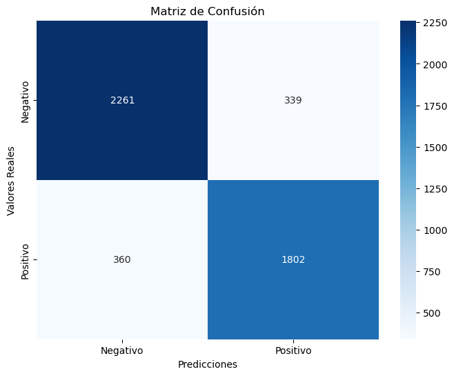

```
149/149 ━━━━━━━━━━━━━━━━━━━━ 0s 709us/step
```

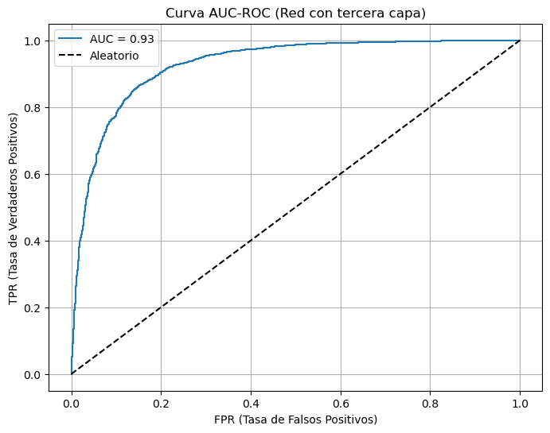

```python
# Visualización de resultados
#plot_training_history(history_with_third)
plot_confusion_matrix_and_metrics(y_test, model_with_third.predict(
    [X_test_general, X_test_cancer_type, X_test_breast, X_test_lung, X_test_prostate]))
plot_auc_roc(y_test, model_with_third.predict(
    [X_test_general, X_test_cancer_type, X_test_breast, X_test_lung, X_test_prostate]), model_name="Red con tercera capa")
```

Se observa unos resultados de validación insuficientes para el resultados esperado, se realizan las siguientes revisiones:

- Regularización Avanzada: Se mantiene Dropout y Batch Normalization para mitigar el sobreajuste.
- Ensemble Learning: Combina las predicciones de ambas redes para mejorar la precisión y estabilidad.

```python
# Tercer modelo: Modelo avanzado

from tensorflow.keras.layers import BatchNormalization
from sklearn.metrics import roc_auc_score
import numpy as np
# Definición del modelo avanzado con ensemble learning
def create_advanced_model(with_extra_layer=True):
    # Entrada general
    general_input = Input(shape=(37,), name="General_Input")

    # Embedding para Cancer Type
    cancer_type_input = Input(shape=(1,), name="Cancer_Type_Input")
    cancer_type_embedding = Embedding(input_dim=num_cancer_types, output_dim=embedding_dim, name="Cancer_Type_Embedding")(cancer_type_input)
    cancer_type_flat = Flatten(name="Flatten_Cancer_Type")(cancer_type_embedding)

    # Subredes específicas
    breast_input = Input(shape=(len(breast_cancer_cols),), name="Breast_Input")
    breast_hidden = Dense(16, activation="relu", name="Breast_Hidden")(breast_input)

    lung_input = Input(shape=(len(lung_cancer_cols),), name="Lung_Input")
    lung_hidden = Dense(16, activation="relu", name="Lung_Hidden")(lung_input)

    prostate_input = Input(shape=(len(prostate_cancer_cols),), name="Prostate_Input")
    prostate_hidden = Dense(16, activation="relu", name="Prostate_Hidden")(prostate_input)

    # Concatenación
    merged = concatenate([general_input, cancer_type_flat, breast_hidden, lung_hidden, prostate_hidden], name="Concatenate_Layer")

    # Capas ocultas generales con Batch Normalization
    hidden_1 = Dense(64, activation="relu", name="Hidden_Layer_1")(merged)
    hidden_1 = BatchNormalization()(hidden_1)
    dropout_1 = Dropout(0.2, name="Dropout_1")(hidden_1)

    hidden_2 = Dense(32, activation="relu", name="Hidden_Layer_2")(dropout_1)
    hidden_2 = BatchNormalization()(hidden_2)

    if with_extra_layer:
        hidden_3 = Dense(16, activation="relu", name="Hidden_Layer_3")(hidden_2)
        dropout_2 = Dropout(0.2, name="Dropout_2")(hidden_3)
        output = Dense(1, activation="sigmoid", name="Output")(dropout_2)
    else:
        output = Dense(1, activation="sigmoid", name="Output")(hidden_2)

    # Construcción del modelo
    model = Model(inputs=[general_input, cancer_type_input, breast_input, lung_input, prostate_input], outputs=output, name="Modelo_con_division_en_subredes_por_tipo_de_cancer_con_assemble_learning")
    model.compile(optimizer=tf.keras.optimizers.Adam(learning_rate=lr), loss="binary_crossentropy", metrics=["accuracy"])

    return model

# Crear modelos
from sklearn.model_selection import KFold
from sklearn.metrics import accuracy_score, roc_auc_score
import numpy as np

# Definir validación cruzada con KFold
kf = KFold(n_splits=5, shuffle=True, random_state=42)

# Listas para almacenar resultados
accuracy_scores_no_extra = []
auc_scores_no_extra = []
accuracy_scores_with_extra = []
auc_scores_with_extra = []

# Validación cruzada
for train_index, val_index in kf.split(X_train_general):
    # Para DataFrame de Pandas (usar .iloc)
    X_train_fold_general = X_train_general.iloc[train_index]
    X_val_fold_general = X_train_general.iloc[val_index]

    X_train_fold_cancer = X_train_cancer_type.iloc[train_index]
    X_val_fold_cancer = X_train_cancer_type.iloc[val_index]

    y_train_fold = y_train.iloc[train_index]
    y_val_fold = y_train.iloc[val_index]

    X_train_fold_breast = X_train_breast.iloc[train_index]
    X_val_fold_breast = X_train_breast.iloc[val_index]

    X_train_fold_lung = X_train_lung.iloc[train_index]
    X_val_fold_lung = X_train_lung.iloc[val_index]

    X_train_fold_prostate = X_train_prostate.iloc[train_index]
    X_val_fold_prostate = X_train_prostate.iloc[val_index]

    # Crear modelos para cada pliegue
    model_no_extra = create_advanced_model(with_extra_layer=False)
    model_with_extra = create_advanced_model(with_extra_layer=True)

    # Entrenamiento de los modelos con validación cruzada
    history_no_extra = model_no_extra.fit(
        [X_train_fold_general, X_train_fold_cancer, X_train_fold_breast, X_train_fold_lung, X_train_fold_prostate],
        y_train_fold,
        validation_data=([X_val_fold_general, X_val_fold_cancer, X_val_fold_breast, X_val_fold_lung, X_val_fold_prostate], y_val_fold),
        epochs=150,
        batch_size=32,
        callbacks=[early_stop],
        verbose=0
    )

    history_with_extra = model_with_extra.fit(
        [X_train_fold_general, X_train_fold_cancer, X_train_fold_breast, X_train_fold_lung, X_train_fold_prostate],
        y_train_fold,
        validation_data=([X_val_fold_general, X_val_fold_cancer, X_val_fold_breast, X_val_fold_lung, X_val_fold_prostate], y_val_fold),
        epochs=150,
        batch_size=32,
        callbacks=[early_stop],
        verbose=0
    )

    # Predicciones y métricas
    y_val_pred_no_extra = model_no_extra.predict([X_val_fold_general, X_val_fold_cancer, X_val_fold_breast, X_val_fold_lung, X_val_fold_prostate])
    y_val_pred_binary_no_extra = (y_val_pred_no_extra > 0.5).astype(int)

    y_val_pred_with_extra = model_with_extra.predict([X_val_fold_general, X_val_fold_cancer, X_val_fold_breast, X_val_fold_lung, X_val_fold_prostate])
    y_val_pred_binary_with_extra = (y_val_pred_with_extra > 0.5).astype(int)

    accuracy_no_extra = accuracy_score(y_val_fold, y_val_pred_binary_no_extra)
    auc_no_extra = roc_auc_score(y_val_fold, y_val_pred_no_extra)

    accuracy_with_extra = accuracy_score(y_val_fold, y_val_pred_binary_with_extra)
    auc_with_extra = roc_auc_score(y_val_fold, y_val_pred_with_extra)

    accuracy_scores_no_extra.append(accuracy_no_extra)
    auc_scores_no_extra.append(auc_no_extra)

    accuracy_scores_with_extra.append(accuracy_with_extra)
    auc_scores_with_extra.append(auc_with_extra)

# Promedios de validación cruzada
mean_accuracy_no_extra = np.mean(accuracy_scores_no_extra)
mean_auc_no_extra = np.mean(auc_scores_no_extra)

mean_accuracy_with_extra = np.mean(accuracy_scores_with_extra)
mean_auc_with_extra = np.mean(auc_scores_with_extra)

print(f"\nModelo sin tercera capa - Precisión promedio de aprendizaje en validación cruzada: {mean_accuracy_no_extra:.4f}")
print(f"Modelo sin tercera capa - AUC-ROC promedio de aprendizaje en validación cruzada: {mean_auc_no_extra:.4f}")

print(f"\nModelo con tercera capa - Precisión promedio de aprendizaje en validación cruzada: {mean_accuracy_with_extra:.4f}")
print(f"Modelo con tercera capa - AUC-ROC promedio en aprendizaje validación cruzada: {mean_auc_with_extra:.4f}")
```

```
120/120 ━━━━━━━━━━━━━━━━━━━━ 0s 1ms/step
120/120 ━━━━━━━━━━━━━━━━━━━━ 0s 1ms/step
120/120 ━━━━━━━━━━━━━━━━━━━━ 0s 1ms/step
120/120 ━━━━━━━━━━━━━━━━━━━━ 0s 1ms/step
120/120 ━━━━━━━━━━━━━━━━━━━━ 0s 1ms/step
120/120 ━━━━━━━━━━━━━━━━━━━━ 0s 1ms/step
120/120 ━━━━━━━━━━━━━━━━━━━━ 0s 1ms/step
120/120 ━━━━━━━━━━━━━━━━━━━━ 0s 1ms/step
120/120 ━━━━━━━━━━━━━━━━━━━━ 0s 1ms/step
120/120 ━━━━━━━━━━━━━━━━━━━━ 0s 1ms/step

Modelo sin tercera capa - Precisión promedio de aprendizaje en validación cruzada: 0.8635
Modelo sin tercera capa - AUC-ROC promedio de aprendizaje en validación cruzada: 0.9309

Modelo con tercera capa - Precisión promedio de aprendizaje en validación cruzada: 0.8639
Modelo con tercera capa - AUC-ROC promedio en aprendizaje validación cruzada: 0.9316
```

```python
# Ensemble Learning para combinar predicciones finales
predictions_no_extra = model_no_extra.predict(
    [X_test_general, X_test_cancer_type, X_test_breast, X_test_lung, X_test_prostate]
)
predictions_with_extra = model_with_extra.predict(
    [X_test_general, X_test_cancer_type, X_test_breast, X_test_lung, X_test_prostate]
)

final_predictions = (predictions_no_extra + predictions_with_extra) / 2
final_predictions_binary = (final_predictions > 0.5).astype(int)

# Evaluación final del modelo ensemble
auc_score_ensemble = roc_auc_score(y_test, final_predictions)
final_accuracy = accuracy_score(y_test, final_predictions_binary)
print(f"AUC-ROC Score del Ensemble después de validación cruzada: {auc_score_ensemble:.4f}")
print(f"\nModelo Ensemble - Precisión total: {final_accuracy:.4f}")
```

```
149/149 ━━━━━━━━━━━━━━━━━━━━ 0s 736us/step
149/149 ━━━━━━━━━━━━━━━━━━━━ 0s 750us/step
AUC-ROC Score del Ensemble después de validación cruzada: 0.9295

Modelo Ensemble - Precisión total: 0.8547
```

### 3.3- Modelos sin división de subredes específicas por tipo de cáncer

Una vez obtenidos los resultados, se realiza la comparativa con el modelo sin división en subredes. El que arroje mejores resultados, se optimizará.

```python
# Cuarto modelo: sin division de subredes con 2 capas ocultas
# Crear la red sin división de parámetros y solo dos capas
# Entradas
cancer_type_input = Input(shape=(1,), name='cancer_type_input')  # Entrada para tipo de cáncer
other_features_input = Input(shape=(X.shape[1] - 1,), name='other_features_input')  # Otras características

# Capa de embeddings para Cancer Type
cancer_embedding = Embedding(input_dim=num_cancer_types, output_dim=embedding_dim, name='cancer_embedding')(cancer_type_input)
cancer_embedding_flattened = Flatten()(cancer_embedding)

# Concatenar embeddings con otras características
concatenated_features = Concatenate()([cancer_embedding_flattened, other_features_input])

# Capas ocultas
dense1 = Dense(64, activation='relu')(concatenated_features)
dropout1 = Dropout(0.2)(dense1)  # Dropout opcional
dense2 = Dense(32, activation='relu')(dropout1)
output = Dense(1, activation='sigmoid')(dense2)

# Modelo sin tercera capa
model_no_third_2 = Model(inputs=[cancer_type_input, other_features_input], outputs=output, name="Modelo_de_dos_capas_ocultas_sin_division_en_subredes_por_tipo_de_cancer")

# Compilar el modelo
model_no_third_2.compile(optimizer='adam', loss='binary_crossentropy', metrics=['accuracy'])
model_no_third_2.summary()
```

```
Model: "Modelo_de_dos_capas_ocultas_sin_division_en_subredes_por_tipo_de_cancer"
```

```
┏━━━━━━━━━━━━━━━━━━━━━┳━━━━━━━━━━━━━━━━━━━┳━━━━━━━━━━━━┳━━━━━━━━━━━━━━━━━━━┓
┃ Layer (type)        ┃ Output Shape      ┃    Param # ┃ Connected to      ┃
┡━━━━━━━━━━━━━━━━━━━━━╇━━━━━━━━━━━━━━━━━━━╇━━━━━━━━━━━━╇━━━━━━━━━━━━━━━━━━━┩
│ cancer_type_input   │ (None, 1)         │          0 │ -                 │
│ (InputLayer)        │                   │            │                   │
├─────────────────────┼───────────────────┼────────────┼───────────────────┤
│ cancer_embedding    │ (None, 1, 8)      │         40 │ cancer_type_inpu… │
│ (Embedding)         │                   │            │                   │
├─────────────────────┼───────────────────┼────────────┼───────────────────┤
│ flatten (Flatten)   │ (None, 8)         │          0 │ cancer_embedding… │
├─────────────────────┼───────────────────┼────────────┼───────────────────┤
│ other_features_inp… │ (None, 42)        │          0 │ -                 │
│ (InputLayer)        │                   │            │                   │
├─────────────────────┼───────────────────┼────────────┼───────────────────┤
│ concatenate         │ (None, 50)        │          0 │ flatten[0][0],    │
│ (Concatenate)       │                   │            │ other_features_i… │
├─────────────────────┼───────────────────┼────────────┼───────────────────┤
│ dense (Dense)       │ (None, 64)        │      3,264 │ concatenate[0][0] │
├─────────────────────┼───────────────────┼────────────┼───────────────────┤
│ dropout (Dropout)   │ (None, 64)        │          0 │ dense[0][0]       │
├─────────────────────┼───────────────────┼────────────┼───────────────────┤
│ dense_1 (Dense)     │ (None, 32)        │      2,080 │ dropout[0][0]     │
├─────────────────────┼───────────────────┼────────────┼───────────────────┤
│ dense_2 (Dense)     │ (None, 1)         │         33 │ dense_1[0][0]     │
└─────────────────────┴───────────────────┴────────────┴───────────────────┘
```

```
 Total params: 5,417 (21.16 KB)
```

```
 Trainable params: 5,417 (21.16 KB)
```

```
 Non-trainable params: 0 (0.00 B)
```

```python
# Entradas tienen el formato correcto
X_train_cancer_type = X_train['Cancer Type'].values.reshape(-1, 1)  # Convertir a matriz 2D
X_test_cancer_type = X_test['Cancer Type'].values.reshape(-1, 1)

X_train_other_features = X_train.drop(columns=['Cancer Type']).values  # Convertir a numpy array
X_test_other_features = X_test.drop(columns=['Cancer Type']).values

# Combinar las entradas en una sola matriz
X_train_combined = np.hstack([X_train_cancer_type, X_train_other_features])  # Combina cancer type y otras características
X_test_combined = np.hstack([X_test_cancer_type, X_test_other_features])  # Igual para datos de prueba

# Verificar dimensiones
print(f"X_train_combined: {X_train_combined.shape}")  # Debe ser (n_samples, n_features)
print(f"y_train: {y_train.shape}")  # Debe coincidir en tamaño con X_train_combined
```

```
X_train_combined: (19046, 43)
y_train: (19046,)
```

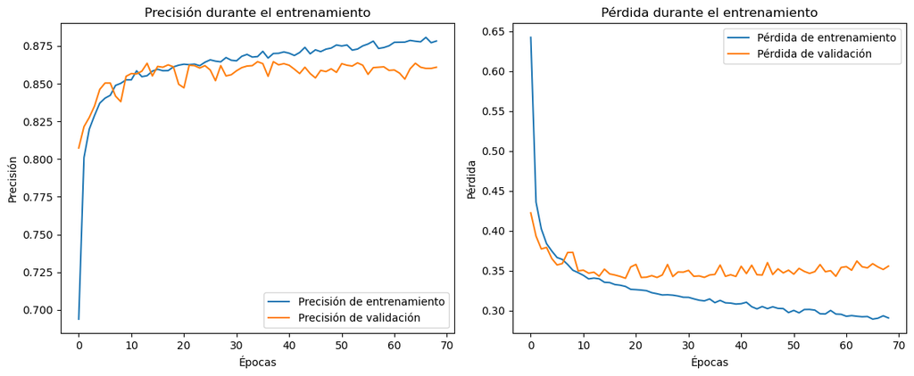

```
120/120 ━━━━━━━━━━━━━━━━━━━━ 0s 781us/step
120/120 ━━━━━━━━━━━━━━━━━━━━ 0s 630us/step
120/120 ━━━━━━━━━━━━━━━━━━━━ 0s 571us/step
120/120 ━━━━━━━━━━━━━━━━━━━━ 0s 580us/step
120/120 ━━━━━━━━━━━━━━━━━━━━ 0s 571us/step

Red sin tercera capa sin división de parámetros - Precisión promedio de aprendizaje en validación cruzada: 0.8694
Red sin tercera capa sin división de parámetros - AUC-ROC promedio de aprendizaje en validación cruzada: 0.9388
149/149 ━━━━━━━━━━━━━━━━━━━━ 0s 736us/step - accuracy: 0.8570 - loss: 0.3424

Valores de evaluación del modelo 4: Red sin tercera capa sin división de subredes - Pérdida: 0.3432, Precisión: 85.4053%
```

```python
# Listas para almacenar resultados
accuracy_scores = []
auc_scores = []
# Contador de iteraciones
first_iteration = True
# Validación cruzada
for train_index, val_index in kf.split(X_train_cancer_type):
    # División de datos para el pliegue actual
    X_train_fold_cancer = X_train_cancer_type[train_index]
    X_val_fold_cancer = X_train_cancer_type[val_index]

    X_train_fold_other = X_train_other_features[train_index]
    X_val_fold_other = X_train_other_features[val_index]

    y_train_fold = y_train.iloc[train_index]
    y_val_fold = y_train.iloc[val_index]

    history_no_third_2 = model_no_third_2.fit(
        [X_train_fold_cancer, X_train_fold_other], y_train_fold,
        validation_data=([X_val_fold_cancer, X_val_fold_other], y_val_fold),
        epochs=150,
        batch_size=32,
        callbacks=[early_stop],
        verbose=0
    )
    if first_iteration: # Mostrar primera funcion de entrenamiento
        plot_training_history(history_no_third_2)
        first_iteration = False  # Cambiar a False para no volver a mostrarla

    # Evaluar el modelo en el conjunto de validación
    y_val_pred = model_no_third_2.predict([X_val_fold_cancer, X_val_fold_other])
    y_val_pred_binary = (y_val_pred > 0.5).astype(int)

    accuracy = accuracy_score(y_val_fold, y_val_pred_binary)
    auc = roc_auc_score(y_val_fold, y_val_pred)

    accuracy_scores.append(accuracy)
    auc_scores.append(auc)

# Cálculo de métricas finales
mean_accuracy_no_third_2 = np.mean(accuracy_scores)
mean_auc_no_third_2 = np.mean(auc_scores)
print(f"\nRed sin tercera capa sin división de parámetros - Precisión promedio de aprendizaje en validación cruzada: {mean_accuracy_no_third_2:.4f}")
print(f"Red sin tercera capa sin división de parámetros - AUC-ROC promedio de aprendizaje en validación cruzada: {mean_auc_no_third_2:.4f}")

# Evaluación final del modelo en el conjunto de prueba
loss_no_third_2, accuracy_no_third_2 = model_no_third_2.evaluate(
    [X_test_cancer_type, X_test_other_features], y_test
)
print(f"\nValores de evaluación del modelo 4: Red sin tercera capa sin división de subredes - Pérdida: {loss_no_third_2:.4f}, Precisión: {accuracy_no_third_2:.4%}")
```

```
149/149 ━━━━━━━━━━━━━━━━━━━━ 0s 561us/step
Verdaderos Negativos (TN): 2292
Falsos Positivos (FP): 308
Falsos Negativos (FN): 387
Verdaderos Positivos (TP): 1775

Clasificación detallada:
              precision    recall  f1-score   support

           0       0.86      0.88      0.87      2600
           1       0.85      0.82      0.84      2162

    accuracy                           0.85      4762
   macro avg       0.85      0.85      0.85      4762
weighted avg       0.85      0.85      0.85      4762
```

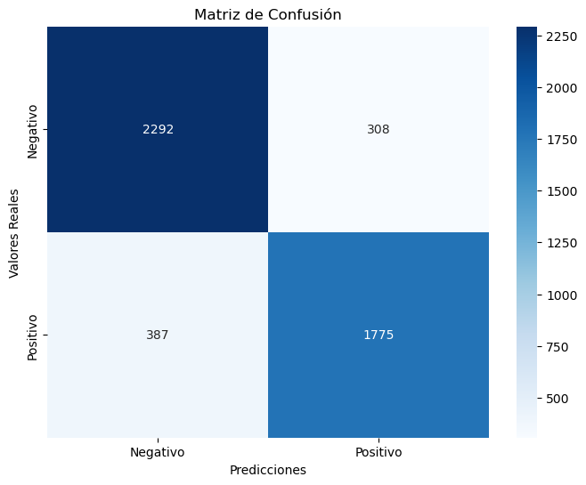

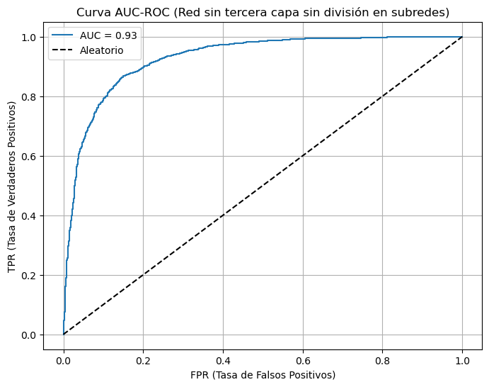

```python
# Visualización de métricas
#plot_training_history(history_no_third_2)
y_pred_no_third_2 = model_no_third_2.predict([X_test_cancer_type, X_test_other_features])
plot_confusion_matrix_and_metrics(y_test, y_pred_no_third_2)
plot_auc_roc(y_test, y_pred_no_third_2, model_name="Red sin tercera capa sin división en subredes")
```

```python
# Modelo 5: Añadir una tercera capa oculta
dense3 = Dense(16, activation='relu')(dense2)
dropout2 = Dropout(0.2)(dense3)  # Dropout opcional
output_with_third = Dense(1, activation='sigmoid')(dropout2)

# Modelo con tercera capa
model_with_third_2 = Model(inputs=[cancer_type_input, other_features_input], outputs=output_with_third, name="Modelo_de_tres_capas_ocultas_sin_division_en_subredes_por_tipo_de_cancer")

# Compilar el modelo
model_with_third_2.compile(optimizer='adam', loss='binary_crossentropy', metrics=['accuracy'])
model_with_third_2.summary()
```

```
Model: "Modelo_de_tres_capas_ocultas_sin_division_en_subredes_por_tipo_de_cancer"
```

```
┏━━━━━━━━━━━━━━━━━━━━━┳━━━━━━━━━━━━━━━━━━━┳━━━━━━━━━━━━┳━━━━━━━━━━━━━━━━━━━┓
┃ Layer (type)        ┃ Output Shape      ┃    Param # ┃ Connected to      ┃
┡━━━━━━━━━━━━━━━━━━━━━╇━━━━━━━━━━━━━━━━━━━╇━━━━━━━━━━━━╇━━━━━━━━━━━━━━━━━━━┩
│ cancer_type_input   │ (None, 1)         │          0 │ -                 │
│ (InputLayer)        │                   │            │                   │
├─────────────────────┼───────────────────┼────────────┼───────────────────┤
│ cancer_embedding    │ (None, 1, 8)      │         40 │ cancer_type_inpu… │
│ (Embedding)         │                   │            │                   │
├─────────────────────┼───────────────────┼────────────┼───────────────────┤
│ flatten_2 (Flatten) │ (None, 8)         │          0 │ cancer_embedding… │
├─────────────────────┼───────────────────┼────────────┼───────────────────┤
│ other_features_inp… │ (None, 42)        │          0 │ -                 │
│ (InputLayer)        │                   │            │                   │
├─────────────────────┼───────────────────┼────────────┼───────────────────┤
│ concatenate         │ (None, 50)        │          0 │ flatten_2[0][0],  │
│ (Concatenate)       │                   │            │ other_features_i… │
├─────────────────────┼───────────────────┼────────────┼───────────────────┤
│ dense (Dense)       │ (None, 64)        │      3,264 │ concatenate[0][0] │
├─────────────────────┼───────────────────┼────────────┼───────────────────┤
│ dropout (Dropout)   │ (None, 64)        │          0 │ dense[0][0]       │
├─────────────────────┼───────────────────┼────────────┼───────────────────┤
│ dense_1 (Dense)     │ (None, 32)        │      2,080 │ dropout[0][0]     │
├─────────────────────┼───────────────────┼────────────┼───────────────────┤
│ dense_3 (Dense)     │ (None, 16)        │        528 │ dense_1[0][0]     │
├─────────────────────┼───────────────────┼────────────┼───────────────────┤
│ dropout_1 (Dropout) │ (None, 16)        │          0 │ dense_3[0][0]     │
├─────────────────────┼───────────────────┼────────────┼───────────────────┤
│ dense_4 (Dense)     │ (None, 1)         │         17 │ dropout_1[0][0]   │
└─────────────────────┴───────────────────┴────────────┴───────────────────┘
```

```
 Total params: 5,929 (23.16 KB)
```

```
 Trainable params: 5,929 (23.16 KB)
```

```
 Non-trainable params: 0 (0.00 B)
```

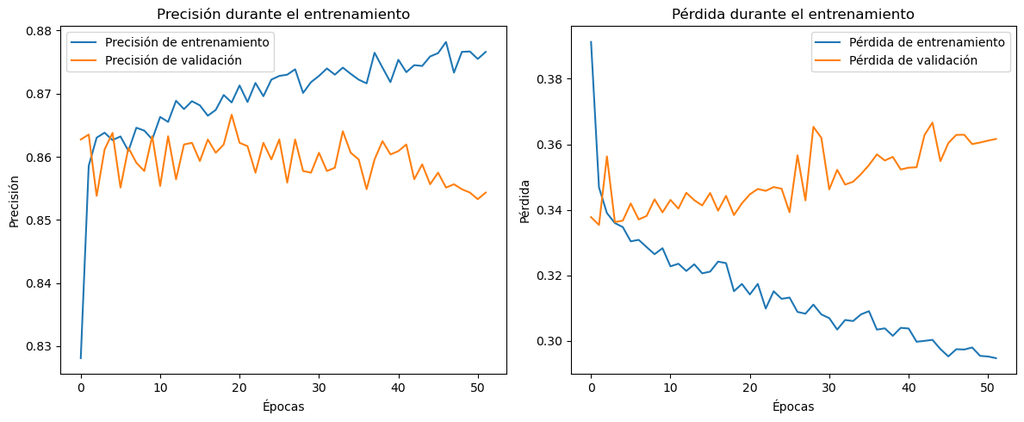

```
120/120 ━━━━━━━━━━━━━━━━━━━━ 0s 857us/step
120/120 ━━━━━━━━━━━━━━━━━━━━ 0s 580us/step
120/120 ━━━━━━━━━━━━━━━━━━━━ 0s 588us/step
120/120 ━━━━━━━━━━━━━━━━━━━━ 0s 580us/step
120/120 ━━━━━━━━━━━━━━━━━━━━ 0s 580us/step

Modelo con tercera capa - Precisión promedio de aprendizaje en validación cruzada: 0.8719
Modelo con tercera capa - AUC-ROC promedio de aprendizaje en validación cruzada: 0.9392
149/149 ━━━━━━━━━━━━━━━━━━━━ 0s 696us/step - accuracy: 0.8503 - loss: 0.3466

Valores de evaluación del modelo 5: Red con tercera capa sin división de subredes - Pérdida: 0.3455, Precisión: 85.2793%
```

```python
from sklearn.model_selection import KFold
from sklearn.metrics import accuracy_score, roc_auc_score
import numpy as np

# Definir validación cruzada con KFold
kf = KFold(n_splits=5, shuffle=True, random_state=42)

# Listas para almacenar resultados
accuracy_scores = []
auc_scores = []
# Contador de iteraciones
first_iteration = True
# Validación cruzada
for train_index, val_index in kf.split(X_train_cancer_type):
    # División de datos para el pliegue actual
    X_train_fold_cancer = X_train_cancer_type[train_index]
    X_val_fold_cancer = X_train_cancer_type[val_index]

    X_train_fold_other = X_train_other_features[train_index]
    X_val_fold_other = X_train_other_features[val_index]

    y_train_fold = y_train.iloc[train_index]
    y_val_fold = y_train.iloc[val_index]

    history_with_third_2 = model_with_third_2.fit(
        [X_train_fold_cancer, X_train_fold_other], y_train_fold,
        validation_data=([X_val_fold_cancer, X_val_fold_other], y_val_fold),
        epochs=150,
        batch_size=32,
        callbacks=[early_stop],
        verbose=0
    )
    if first_iteration: # Mostrar primera funcion de entrenamiento
        plot_training_history(history_with_third_2)
        first_iteration = False  # Cambiar a False para no volver a mostrarla

    # Evaluar el modelo en el conjunto de validación
    y_val_pred = model_with_third_2.predict([X_val_fold_cancer, X_val_fold_other])
    y_val_pred_binary = (y_val_pred > 0.5).astype(int)

    accuracy = accuracy_score(y_val_fold, y_val_pred_binary)
    auc = roc_auc_score(y_val_fold, y_val_pred)

    accuracy_scores.append(accuracy)
    auc_scores.append(auc)

# Cálculo de métricas finales tras aprendizaje con validación cruzada
mean_accuracy_with_third_2 = np.mean(accuracy_scores)
mean_auc_with_third_2 = np.mean(auc_scores)

print(f"\nModelo con tercera capa - Precisión promedio de aprendizaje en validación cruzada: {mean_accuracy_with_third_2:.4f}")
print(f"Modelo con tercera capa - AUC-ROC promedio de aprendizaje en validación cruzada: {mean_auc_with_third_2:.4f}")

# Evaluación del modelo con tercera capa en conjunto de prueba
loss_with_third_2, accuracy_with_third_2 = model_with_third_2.evaluate(
    [X_test_cancer_type, X_test_other_features], y_test
)

print(f"\nValores de evaluación del modelo 5: Red con tercera capa sin división de subredes - Pérdida: {loss_with_third_2:.4f}, Precisión: {accuracy_with_third_2:.4%}")
```

```
149/149 ━━━━━━━━━━━━━━━━━━━━ 0s 581us/step
Verdaderos Negativos (TN): 2223
Falsos Positivos (FP): 377
Falsos Negativos (FN): 324
Verdaderos Positivos (TP): 1838

Clasificación detallada:
              precision    recall  f1-score   support

           0       0.87      0.85      0.86      2600
           1       0.83      0.85      0.84      2162

    accuracy                           0.85      4762
   macro avg       0.85      0.85      0.85      4762
weighted avg       0.85      0.85      0.85      4762
```

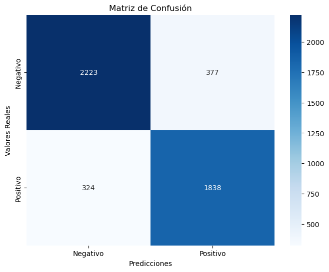

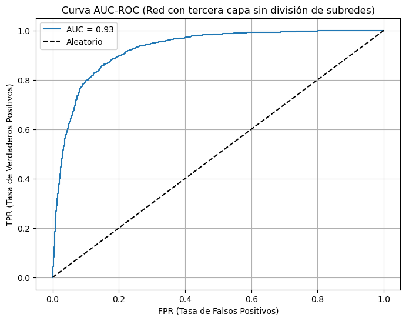

```python
# Visualización de métricas
#plot_training_history(history_with_third_2)
y_pred_with_third_2 = model_with_third_2.predict([X_test_cancer_type, X_test_other_features])
plot_confusion_matrix_and_metrics(y_test, y_pred_with_third_2)
plot_auc_roc(y_test, y_pred_with_third_2, model_name="Red con tercera capa sin división de subredes")
```

```python
# Sexto modelo: Modelo avanzado
# Definición del modelo avanzado con ensemble learning
def create_assembly_model_2(with_extra_layer=True):
    # Entradas principales
    cancer_type_input = Input(shape=(1,), name='cancer_type_input')
    other_features_input = Input(shape=(X.shape[1] - 1,), name='other_features_input')

    # Embedding para Cancer Type
    cancer_embedding = Embedding(input_dim=num_cancer_types, output_dim=embedding_dim, name='cancer_embedding')(cancer_type_input)
    cancer_embedding_flattened = Flatten()(cancer_embedding)

    # Concatenación de características
    concatenated_features = Concatenate()([cancer_embedding_flattened, other_features_input])

    # Capas ocultas con Batch Normalization y Dropout
    hidden_1 = Dense(64, activation='relu')(concatenated_features)
    hidden_1 = BatchNormalization()(hidden_1)
    dropout_1 = Dropout(0.2)(hidden_1)

    hidden_2 = Dense(32, activation='relu')(dropout_1)
    hidden_2 = BatchNormalization()(hidden_2)

    if with_extra_layer:
        # Tercera capa opcional
        hidden_3 = Dense(16, activation='relu')(hidden_2)
        dropout_2 = Dropout(0.2)(hidden_3)
        output = Dense(1, activation='sigmoid')(dropout_2)
    else:
        output = Dense(1, activation='sigmoid')(hidden_2)

    # Crear el modelo
    model = Model(inputs=[cancer_type_input, other_features_input], outputs=output, name="Modelo_sin_division_en_subredes_por_tipo_de_cancer_con_assemble_learning")
    model.compile(optimizer=tf.keras.optimizers.Adam(learning_rate=lr), loss='binary_crossentropy', metrics=['accuracy'])
    return model

# Crear modelos
# Definir validación cruzada con KFold
kf = KFold(n_splits=5, shuffle=True, random_state=42)

# Listas para almacenar resultados
accuracy_scores_no_extra = []
auc_scores_no_extra = []
accuracy_scores_with_extra = []
auc_scores_with_extra = []

# Validación cruzada
for train_index, val_index in kf.split(X_train_cancer_type):
    # División de datos para el pliegue actual
    X_train_fold_cancer = X_train_cancer_type[train_index]
    X_val_fold_cancer = X_train_cancer_type[val_index]

    X_train_fold_other = X_train_other_features[train_index]
    X_val_fold_other = X_train_other_features[val_index]

    y_train_fold = y_train.iloc[train_index]
    y_val_fold = y_train.iloc[val_index]

    # Crear y entrenar los modelos para el pliegue actual
    model_no_extra_2 = create_assembly_model_2(with_extra_layer=False)
    model_with_extra_2 = create_assembly_model_2(with_extra_layer=True)

    history_no_extra_2 = model_no_extra_2.fit(
        [X_train_fold_cancer, X_train_fold_other],
        y_train_fold,
        validation_data=([X_val_fold_cancer, X_val_fold_other], y_val_fold),
        epochs=150,
        batch_size=32,
        callbacks=[early_stop],
        verbose=0
    )

    history_with_extra_2 = model_with_extra_2.fit(
        [X_train_fold_cancer, X_train_fold_other],
        y_train_fold,
        validation_data=([X_val_fold_cancer, X_val_fold_other], y_val_fold),
        epochs=150,
        batch_size=32,
        callbacks=[early_stop],
        verbose=0
    )


    # Predicciones y métricas
    y_val_pred_no_extra = model_no_extra_2.predict([X_val_fold_cancer, X_val_fold_other])
    y_val_pred_binary_no_extra = (y_val_pred_no_extra > 0.5).astype(int)

    y_val_pred_with_extra = model_with_extra_2.predict([X_val_fold_cancer, X_val_fold_other])
    y_val_pred_binary_with_extra = (y_val_pred_with_extra > 0.5).astype(int)

    accuracy_no_extra = accuracy_score(y_val_fold, y_val_pred_binary_no_extra)
    auc_no_extra = roc_auc_score(y_val_fold, y_val_pred_no_extra)

    accuracy_with_extra = accuracy_score(y_val_fold, y_val_pred_binary_with_extra)
    auc_with_extra = roc_auc_score(y_val_fold, y_val_pred_with_extra)

    accuracy_scores_no_extra.append(accuracy_no_extra)
    auc_scores_no_extra.append(auc_no_extra)

    accuracy_scores_with_extra.append(accuracy_with_extra)
    auc_scores_with_extra.append(auc_with_extra)

# Promedios de aprendizaje con validación cruzada
mean_accuracy_no_extra = np.mean(accuracy_scores_no_extra)
mean_auc_no_extra = np.mean(auc_scores_no_extra)

mean_accuracy_with_extra = np.mean(accuracy_scores_with_extra)
mean_auc_with_extra = np.mean(auc_scores_with_extra)

print(f"\nModelo sin tercera capa - Precisión promedio en validación cruzada: {mean_accuracy_no_extra:.4f}")
print(f"Modelo sin tercera capa - AUC-ROC promedio en validación cruzada: {mean_auc_no_extra:.4f}")

print(f"\nModelo con tercera capa - Precisión promedio en validación cruzada: {mean_accuracy_with_extra:.4f}")
print(f"Modelo con tercera capa - AUC-ROC promedio en validación cruzada: {mean_auc_with_extra:.4f}")

# Ensemble Learning para combinar predicciones finales
predictions_no_extra_2 = model_no_extra_2.predict(
    [X_test_cancer_type, X_test_other_features]
)
predictions_with_extra_2 = model_with_extra_2.predict(
    [X_test_cancer_type, X_test_other_features]
)
# Evaluación final
final_predictions = (predictions_no_extra_2 + predictions_with_extra_2) / 2
final_predictions_binary = (final_predictions > 0.5).astype(int)
final_accuracy_2 = accuracy_score(y_test, final_predictions_binary)
print(f"\nValores de evaluación del modelo 6: Red con Ensemble learning sin separación en subredes - Precisión total: {final_accuracy_2:.4%}")
```

```
120/120 ━━━━━━━━━━━━━━━━━━━━ 0s 1ms/step
120/120 ━━━━━━━━━━━━━━━━━━━━ 0s 1ms/step
120/120 ━━━━━━━━━━━━━━━━━━━━ 0s 975us/step
120/120 ━━━━━━━━━━━━━━━━━━━━ 0s 1ms/step
120/120 ━━━━━━━━━━━━━━━━━━━━ 0s 1ms/step
120/120 ━━━━━━━━━━━━━━━━━━━━ 0s 1ms/step
120/120 ━━━━━━━━━━━━━━━━━━━━ 0s 950us/step
120/120 ━━━━━━━━━━━━━━━━━━━━ 0s 1000us/step
120/120 ━━━━━━━━━━━━━━━━━━━━ 0s 1ms/step
120/120 ━━━━━━━━━━━━━━━━━━━━ 0s 1ms/step

Modelo sin tercera capa - Precisión promedio en validación cruzada: 0.8630
Modelo sin tercera capa - AUC-ROC promedio en validación cruzada: 0.9304

Modelo con tercera capa - Precisión promedio en validación cruzada: 0.8626
Modelo con tercera capa - AUC-ROC promedio en validación cruzada: 0.9318
149/149 ━━━━━━━━━━━━━━━━━━━━ 0s 628us/step
149/149 ━━━━━━━━━━━━━━━━━━━━ 0s 1ms/step

Valores de evaluación del modelo 6: Red con Ensemble learning sin separación en subredes - Precisión total: 0.8564
```

```python
# AUC-ROC Score
auc_score_ensemble = roc_auc_score(y_test, final_predictions)
print(f"AUC-ROC Score del Ensemble después de validación cruzada: {auc_score_ensemble:.4f}")
```

```
AUC-ROC Score del Ensemble después de validación cruzada: 0.9287
```

### 3.4- Comparativa con autoencoders y SVM para valorar las métricas obtenidas

Se considera ahora el uso de autoencoders y normalización L2 como comparativa en los resultados:

```python
from tensorflow.keras.regularizers import l2
from sklearn.metrics import roc_auc_score

# Configuración inicial
lr = 0.0001
early_stop = tf.keras.callbacks.EarlyStopping(monitor='val_loss', patience=20, restore_best_weights=True)

# Definición del Autoencoder
def create_autoencoder(input_dim):
    # Codificador
    input_layer = Input(shape=(input_dim,), name="Autoencoder_Input")
    encoded = Dense(128, activation="relu", name="Encoded_Layer_1")(input_layer)
    encoded = BatchNormalization()(encoded)
    encoded = Dense(64, activation="relu", name="Encoded_Layer_2")(encoded)

    # Representación latente
    latent = Dense(32, activation="relu", name="Latent_Space")(encoded)

    # Decodificador
    decoded = Dense(64, activation="relu", name="Decoded_Layer_1")(latent)
    decoded = BatchNormalization()(decoded)
    decoded = Dense(128, activation="relu", name="Decoded_Layer_2")(decoded)
    output_layer = Dense(input_dim, activation="sigmoid", name="Autoencoder_Output")(decoded)

    autoencoder = Model(inputs=input_layer, outputs=output_layer, name="Autoencoder_Model")
    encoder = Model(inputs=input_layer, outputs=latent, name="Encoder_Model")  # Solo para el codificador

    autoencoder.compile(optimizer=tf.keras.optimizers.Adam(learning_rate=lr), loss="mse")
    return autoencoder, encoder

# Crear y entrenar el Autoencoder
input_dim_general = X_train_general.shape[1]
autoencoder, encoder = create_autoencoder(input_dim_general)

# Entrenar el Autoencoder
autoencoder.fit(X_train_general, X_train_general, epochs=50, batch_size=32, validation_split=0.2, callbacks=[early_stop])

# Extraer las representaciones latentes
X_train_general_latent = encoder.predict(X_train_general)
X_test_general_latent = encoder.predict(X_test_general)

# Modelo principal utilizando representaciones latentes
def create_main_model():
    # Entrada latente (desde el Autoencoder)
    latent_input = Input(shape=(32,), name="Latent_Input")

    # Entrada para el tipo de cáncer con Embedding
    cancer_type_input = Input(shape=(1,), name="Cancer_Type_Input")
    cancer_type_embedding = Embedding(input_dim=num_cancer_types, output_dim=8, name="Cancer_Type_Embedding")(cancer_type_input)
    cancer_type_flat = Flatten(name="Flatten_Cancer_Type")(cancer_type_embedding)

    # Entradas específicas
    breast_input = Input(shape=(len(breast_cancer_cols),), name="Breast_Input")
    lung_input = Input(shape=(len(lung_cancer_cols),), name="Lung_Input")
    prostate_input = Input(shape=(len(prostate_cancer_cols),), name="Prostate_Input")

    # Subredes específicas con regularización L2
    breast_hidden = Dense(16, activation="relu", kernel_regularizer=l2(0.01), name="Breast_Hidden")(breast_input)
    lung_hidden = Dense(16, activation="relu", kernel_regularizer=l2(0.01), name="Lung_Hidden")(lung_input)
    prostate_hidden = Dense(16, activation="relu", kernel_regularizer=l2(0.01), name="Prostate_Hidden")(prostate_input)

    # Concatenación de todas las entradas
    merged = concatenate([latent_input, cancer_type_flat, breast_hidden, lung_hidden, prostate_hidden], name="Concatenate_Layer")

    # Capas ocultas generales
    hidden_1 = Dense(64, activation="relu", kernel_regularizer=l2(0.01), name="Hidden_Layer_1")(merged)
    dropout_1 = Dropout(0.3, name="Dropout_1")(hidden_1)
    hidden_2 = Dense(32, activation="relu", kernel_regularizer=l2(0.01), name="Hidden_Layer_2")(dropout_1)

    # Capa de salida
    output = Dense(1, activation="sigmoid", name="Output")(hidden_2)

    # Construir modelo
    model = Model(inputs=[latent_input, cancer_type_input, breast_input, lung_input, prostate_input], outputs=output)
    model.compile(optimizer=tf.keras.optimizers.Adam(learning_rate=lr), loss="binary_crossentropy", metrics=["accuracy"])
    return model

# Crear y entrenar el modelo principal
model = create_main_model()

history = model.fit(
    [X_train_general_latent, X_train_cancer_type, X_train_breast, X_train_lung, X_train_prostate],
    y_train,
    validation_split=0.2,
    epochs=150,
    batch_size=32,
    callbacks=[early_stop]
)

# Evaluación
loss_auto, accuracy_auto = model.evaluate(
    [X_test_general_latent, X_test_cancer_type, X_test_breast, X_test_lung, X_test_prostate],
    y_test
)

print(f"\nDesempeño del modelo principal - Pérdida: {loss_auto:.4f}, Precisión: {accuracy_auto:.4%}")


# Métrica AUC-ROC
predictions = model.predict([X_test_general_latent, X_test_cancer_type, X_test_breast, X_test_lung, X_test_prostate])
auc_score = roc_auc_score(y_test, predictions)
print(f"AUC-ROC Score: {auc_score:.4f}")
```

[output not shown]

[output cut: 152 more lines]

```
477/477 ━━━━━━━━━━━━━━━━━━━━ 1s 1ms/step - accuracy: 0.8102 - loss: 0.4397 - val_accuracy: 0.8024 - val_loss: 0.4553
477/477 ━━━━━━━━━━━━━━━━━━━━ 1s 1ms/step - accuracy: 0.8097 - loss: 0.4452 - val_accuracy: 0.7992 - val_loss: 0.4553
477/477 ━━━━━━━━━━━━━━━━━━━━ 1s 1ms/step - accuracy: 0.8064 - loss: 0.4452 - val_accuracy: 0.8021 - val_loss: 0.4569
477/477 ━━━━━━━━━━━━━━━━━━━━ 1s 1ms/step - accuracy: 0.8068 - loss: 0.4428 - val_accuracy: 0.8034 - val_loss: 0.4545
477/477 ━━━━━━━━━━━━━━━━━━━━ 1s 1ms/step - accuracy: 0.8035 - loss: 0.4490 - val_accuracy: 0.8042 - val_loss: 0.4597
477/477 ━━━━━━━━━━━━━━━━━━━━ 1s 1ms/step - accuracy: 0.8079 - loss: 0.4442 - val_accuracy: 0.8026 - val_loss: 0.4556
477/477 ━━━━━━━━━━━━━━━━━━━━ 1s 1ms/step - accuracy: 0.8012 - loss: 0.4496 - val_accuracy: 0.8026 - val_loss: 0.4542
477/477 ━━━━━━━━━━━━━━━━━━━━ 1s 1ms/step - accuracy: 0.8065 - loss: 0.4447 - val_accuracy: 0.8013 - val_loss: 0.4523
477/477 ━━━━━━━━━━━━━━━━━━━━ 1s 1ms/step - accuracy: 0.8115 - loss: 0.4401 - val_accuracy: 0.8021 - val_loss: 0.4529
477/477 ━━━━━━━━━━━━━━━━━━━━ 1s 1ms/step - accuracy: 0.8054 - loss: 0.4420 - val_accuracy: 0.8013 - val_loss: 0.4535
149/149 ━━━━━━━━━━━━━━━━━━━━ 0s 723us/step - accuracy: 0.8092 - loss: 0.4440

Desempeño del modelo principal - Pérdida: 0.4519, Precisión: 80.2814%
149/149 ━━━━━━━━━━━━━━━━━━━━ 0s 926us/step
AUC-ROC Score: 0.8808
```

Hasta aqui, ahora se generará un SVM

```
Precisión del SVM: 83.0533%
AUC-ROC del SVM: 0.9096
```

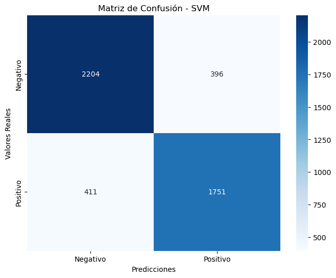

```
Reporte de Clasificación SVM:
              precision    recall  f1-score   support

           0       0.84      0.85      0.85      2600
           1       0.82      0.81      0.81      2162

    accuracy                           0.83      4762
   macro avg       0.83      0.83      0.83      4762
weighted avg       0.83      0.83      0.83      4762
```

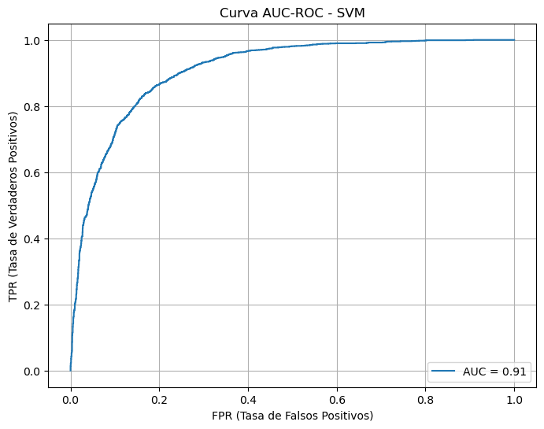

```python
from sklearn.svm import SVC
from sklearn.metrics import roc_auc_score, roc_curve, accuracy_score, confusion_matrix, classification_report

# Normalización y codificación ya aplicada a los datos
# El conjunto de datos X y las etiquetas y ya están preparados

# Crear el conjunto de entrenamiento y prueba
from sklearn.model_selection import train_test_split
X_train, X_test, y_train, y_test = train_test_split(X, y, test_size=0.2, random_state=42, stratify=y)

# Crear el modelo SVM
svm = SVC(kernel='rbf', probability=True, random_state=42)  # Usar kernel RBF y habilitar probabilidades

# Entrenar el modelo
svm.fit(X_train, y_train)

# Predicciones
y_pred_svm = svm.predict(X_test)  # Predicción de clases
y_pred_prob_svm = svm.predict_proba(X_test)[:, 1]  # Probabilidades para AUC-ROC

# Evaluar precisión
accuracy_svm = accuracy_score(y_test, y_pred_svm)
print(f"Precisión del SVM: {accuracy_svm:.4%}")

# Evaluar AUC-ROC
auc_svm = roc_auc_score(y_test, y_pred_prob_svm)
print(f"AUC-ROC del SVM: {auc_svm:.4f}")

# Matriz de Confusión
cm_svm = confusion_matrix(y_test, y_pred_svm)
plt.figure(figsize=(8, 6))
sns.heatmap(cm_svm, annot=True, fmt="d", cmap="Blues", xticklabels=["Negativo", "Positivo"], yticklabels=["Negativo", "Positivo"])
plt.title("Matriz de Confusión - SVM")
plt.xlabel("Predicciones")
plt.ylabel("Valores Reales")
plt.show()

# Reporte de Clasificación
print("\nReporte de Clasificación SVM:")
print(classification_report(y_test, y_pred_svm))

# Curva AUC-ROC
fpr, tpr, _ = roc_curve(y_test, y_pred_prob_svm)
plt.figure(figsize=(8, 6))
plt.plot(fpr, tpr, label=f"AUC = {auc_svm:.2f}")
plt.title("Curva AUC-ROC - SVM")
plt.xlabel("FPR (Tasa de Falsos Positivos)")
plt.ylabel("TPR (Tasa de Verdaderos Positivos)")
plt.legend(loc="lower right")
plt.grid()
plt.show()
```